# House Prices - Avaliando o impacto das características e estimando preço de venda de imóveis

Vitor Caldini

14/10/2020

# 1 Introdução

O documento consiste em uma Análise Exploratória de Dados (EDA), tratamento e preparação de dados (Data Wrangling), avaliação e seleção dos principais parâmetros (Feature Engineering) e modelagem de um algoritmo preditivo para estimativa de preço de venda de imóveis a partir dos algoritmos regressores por regularização Lasso e Gradient Boosting (XGBOOST).

O conjunto de dados utilizado é referente à cidade de Ames, em Iowa nos Estados Unidos. O estudo foi compilado por Dean De Cock e está disponível na plataforma Kaggle, bem como o notebook do autor Erik Bruin, utilizado como referência. O conjunto conta com 2919 residências, descritas por 79 características que serão ordenadas por sua importância no preço de venda do imóvel e manipuladas para modelagem do algoritmo preditivo.

Este tipo de análise visa não somente a criação de um modelo matemático para previsão como também a descoberta de insights a respeito das variáveis que envolvem o mercado imobiliário estudado. Desta forma, entende-se que o estudo possa ser reproduzido para conjuntos de dados brasileiros e servir de direcionamento para ivestimentos de recursos e esforços de incorporadoras, construtores e imobiliárias que buscam aliar eficiência operacional, retorno financeiro e satisfação dos clientes.

## 1.1 Conjunto de dados

Os detalhes sobre as características coletadas dos imóveis, bem como seus parâmetros de preenchimento podem ser consultadas na página do Kaggle (https://www.kaggle.com/c/house-prices-advanced-regression-techniques/data). Vale ressaltar que algumas nomenclaturas como: cômodos acabados, acima da rua, meio-banheiro, dentre outros são traduções livres de termos utilizados no mercado imobiliário estadunidense.

# 2 Carregamento e tratamento preliminar

## 2.1 Pacotes utilizados

```r
library(knitr)
library(ggplot2)
library(kableExtra)
library(plyr)
library(dplyr)
library(caret)
library(corrplot)
library(gridExtra)
library(scales)
library(Rmisc)
library(ggrepel)
library(randomForest)
library(psych)
library(xgboost)
library(glmnet)
```

## 2.2 Leitura dos conjuntos de dados

O conjunto de dados é fornecido já dividido entre treinamento e teste, sendo que o conjunto de teste não possui os valores de venda. Para a modelagem do algoritmo é utilizado somente o conjunto de treinamento, o conjunto de teste (sem preço de venda) é utilizado para teste do algoritmo gerado.

```r
train <- read.csv("train.csv", stringsAsFactors = F)
test <- read.csv("test.csv", stringsAsFactors = F)
```

Para melhor entendimento, os parâmetros foram traduzidos e criada uma tabela com o nome original do parâmetro em inglês e a tradução utlizada a fim de faciliar a consulta nas documentações originais do estudo.

```r
train <- read.csv("train.csv", stringsAsFactors = F)
test <- read.csv("test.csv", stringsAsFactors = F)
test$SalePrice <- NA

nomes_orig <- names(read.csv("train.csv", stringsAsFactors = F))

nomes_portugues <- c("Id","Classe", "Zona", "DimFrontal", "AreaLote", "TipoEstrada", "TipoRua", "RelevoLote", "GreideLote", "Instalacoes", "ImplantacaoLote", "Declive", "Bairro", "Proximidade1", "Proximidade2", "TipoHabitacao", "Pavimentos", "QualidadeTotal", "CondicaoTotal", "AnoConstrucao", "AnoRetrofit", "TipoCobertura", "MaterialCobertura", "Fachada1", "Fachada2", "TipoAlvenaria", "AreaAlvenaria", "QualidadeFachada", "CondicaoFachada", "Fundacao", "AlturaPorao", "CondicaoPorao", "ExposicaoPorao", "RevestimentoPorao1", "AreaPoraoAcabado1", "RevestimentoPorao2", "AreaPoraoAcabado2", "AreaPoraoInacab", "AreaTotalPorao", "Aquecimento", "CondicaoAquecimento", "ArCentral", "SistemaEletrico", "AreaTerreo", "Area1Pav", "AreaAcabBaixaQualTotal", "AreaVivenciaAcimaRua", "BanheirosPorao", "LavaboPorao", "BanheirosAcimaRua", "LavaboAcimaRua", "QuartosAcimaRua", "CozinhasAcimaRua", "QualidadeCozinha", "ComodosAcimarua", "Descontos", "Lareiras", "QualidadeLareira", "TipoGaragem", "AnoGaragem", "AcabamentoGaragem", "VagasGaragem", "AreaGaragem", "QualiGaragem", "CondicaoGaragem", "PavimEntrada", "AreaDeck", "AreaVarandaAberta", "AreaVarandaFechada", "AreaVaranda3Sea", "AreaVarandaScreen", "AreaPiscina", "QualiPiscina", "QualiCerca", "OutrosItens", "ValorItens", "MesVenda", "AnoVenda", "TipoVenda", "CondicaoVenda", "PrecoVenda")

names(train) <- nomes_portugues
names(test) <- nomes_portugues

nomes <- cbind(nomes_orig,nomes_portugues)
```

# 3 Estrutura dos dados e união dos datasets

## 3.1 Treinamento

```r
glimpse(train)
```

```
## Rows: 1,460
## Columns: 81
## $ Id                     <int> 1, 2, 3, 4, 5, 6, 7, 8, 9, 10, 11, 12, 13, 1...
## $ Classe                 <int> 60, 20, 60, 70, 60, 50, 20, 60, 50, 190, 20,...
## $ Zona                   <chr> "RL", "RL", "RL", "RL", "RL", "RL", "RL", "R...
## $ DimFrontal             <int> 65, 80, 68, 60, 84, 85, 75, NA, 51, 50, 70, ...
## $ AreaLote               <int> 8450, 9600, 11250, 9550, 14260, 14115, 10084...
## $ TipoEstrada            <chr> "Pave", "Pave", "Pave", "Pave", "Pave", "Pav...
## $ TipoRua                <chr> NA, NA, NA, NA, NA, NA, NA, NA, NA, NA, NA, ...
## $ RelevoLote             <chr> "Reg", "Reg", "IR1", "IR1", "IR1", "IR1", "R...
## $ GreideLote             <chr> "Lvl", "Lvl", "Lvl", "Lvl", "Lvl", "Lvl", "L...
## $ Instalacoes            <chr> "AllPub", "AllPub", "AllPub", "AllPub", "All...
## $ ImplantacaoLote        <chr> "Inside", "FR2", "Inside", "Corner", "FR2", ...
## $ Declive                <chr> "Gtl", "Gtl", "Gtl", "Gtl", "Gtl", "Gtl", "G...
## $ Bairro                 <chr> "CollgCr", "Veenker", "CollgCr", "Crawfor", ...
```

[output cut: 68 more lines]

```r
dim(train)
```

```
## [1] 1460   81
```

O conjunto de treinamento conta com 1460 observações e 81 variáveis, entre inteiros e caracteres. Ao longo do estudo as variáveis de texto serão convertidas em fatores (categorias), ordinais ou não para poderem ser analisadas.

## 3.2 Teste

```r
glimpse(test)
```

```
## Rows: 1,459
## Columns: 81
## $ Id                     <int> 1461, 1462, 1463, 1464, 1465, 1466, 1467, 14...
## $ Classe                 <int> 20, 20, 60, 60, 120, 60, 20, 60, 20, 20, 120...
## $ Zona                   <chr> "RH", "RL", "RL", "RL", "RL", "RL", "RL", "R...
## $ DimFrontal             <int> 80, 81, 74, 78, 43, 75, NA, 63, 85, 70, 26, ...
## $ AreaLote               <int> 11622, 14267, 13830, 9978, 5005, 10000, 7980...
## $ TipoEstrada            <chr> "Pave", "Pave", "Pave", "Pave", "Pave", "Pav...
## $ TipoRua                <chr> NA, NA, NA, NA, NA, NA, NA, NA, NA, NA, NA, ...
## $ RelevoLote             <chr> "Reg", "IR1", "IR1", "IR1", "IR1", "IR1", "I...
## $ GreideLote             <chr> "Lvl", "Lvl", "Lvl", "Lvl", "HLS", "Lvl", "L...
## $ Instalacoes            <chr> "AllPub", "AllPub", "AllPub", "AllPub", "All...
## $ ImplantacaoLote        <chr> "Inside", "Corner", "Inside", "Inside", "Ins...
## $ Declive                <chr> "Gtl", "Gtl", "Gtl", "Gtl", "Gtl", "Gtl", "G...
## $ Bairro                 <chr> "NAmes", "NAmes", "Gilbert", "Gilbert", "Sto...
```

[output cut: 68 more lines]

```r
dim(test)
```

```
## [1] 1459   81
```

O resumo estatístico - mínimo, máximo, média, mediana, 1o e 3o quartis - das características (colunas) é apresentado a seguir

## 3.3 Conjunto combinado - resumo

```r
todas <- rbind(train, test)
summary(todas)
```

```
##        Id             Classe           Zona             DimFrontal
##  Min.   :   1.0   Min.   : 20.00   Length:2919        Min.   : 21.00
##  1st Qu.: 730.5   1st Qu.: 20.00   Class :character   1st Qu.: 59.00
##  Median :1460.0   Median : 50.00   Mode  :character   Median : 68.00
##  Mean   :1460.0   Mean   : 57.14                      Mean   : 69.31
##  3rd Qu.:2189.5   3rd Qu.: 70.00                      3rd Qu.: 80.00
##  Max.   :2919.0   Max.   :190.00                      Max.   :313.00
##                                                       NA's   :486
##     AreaLote      TipoEstrada          TipoRua           RelevoLote
##  Min.   :  1300   Length:2919        Length:2919        Length:2919
##  1st Qu.:  7478   Class :character   Class :character   Class :character
##  Median :  9453   Mode  :character   Mode  :character   Mode  :character
##  Mean   : 10168
##  3rd Qu.: 11570
##  Max.   :215245
##
##   GreideLote        Instalacoes        ImplantacaoLote      Declive
##  Length:2919        Length:2919        Length:2919        Length:2919
##  Class :character   Class :character   Class :character   Class :character
##  Mode  :character   Mode  :character   Mode  :character   Mode  :character
##
##
##
##
##     Bairro          Proximidade1       Proximidade2       TipoHabitacao
##  Length:2919        Length:2919        Length:2919        Length:2919
##  Class :character   Class :character   Class :character   Class :character
##  Mode  :character   Mode  :character   Mode  :character   Mode  :character
##
##
##
##
##   Pavimentos        QualidadeTotal   CondicaoTotal   AnoConstrucao
##  Length:2919        Min.   : 1.000   Min.   :1.000   Min.   :1872
##  Class :character   1st Qu.: 5.000   1st Qu.:5.000   1st Qu.:1954
##  Mode  :character   Median : 6.000   Median :5.000   Median :1973
##                     Mean   : 6.089   Mean   :5.565   Mean   :1971
##                     3rd Qu.: 7.000   3rd Qu.:6.000   3rd Qu.:2001
##                     Max.   :10.000   Max.   :9.000   Max.   :2010
##
```

[output cut: 113 more lines]

```
##  Min.   : 1.000   Min.   :2006   Length:2919        Length:2919
##  1st Qu.: 4.000   1st Qu.:2007   Class :character   Class :character
##  Median : 6.000   Median :2008   Mode  :character   Mode  :character
##  Mean   : 6.213   Mean   :2008
##  3rd Qu.: 8.000   3rd Qu.:2009
##  Max.   :12.000   Max.   :2010
##
##    PrecoVenda
##  Min.   : 34900
##  1st Qu.:129975
##  Median :163000
##  Mean   :180921
##  3rd Qu.:214000
##  Max.   :755000
##  NA's   :1459
```

# 4 Conhecendo os dados - visualizações preliminares

## 4.1 Conhecendo a variável alvo - Preço de venda

A linha tracejada representa a média e a linha contínua a mediana.

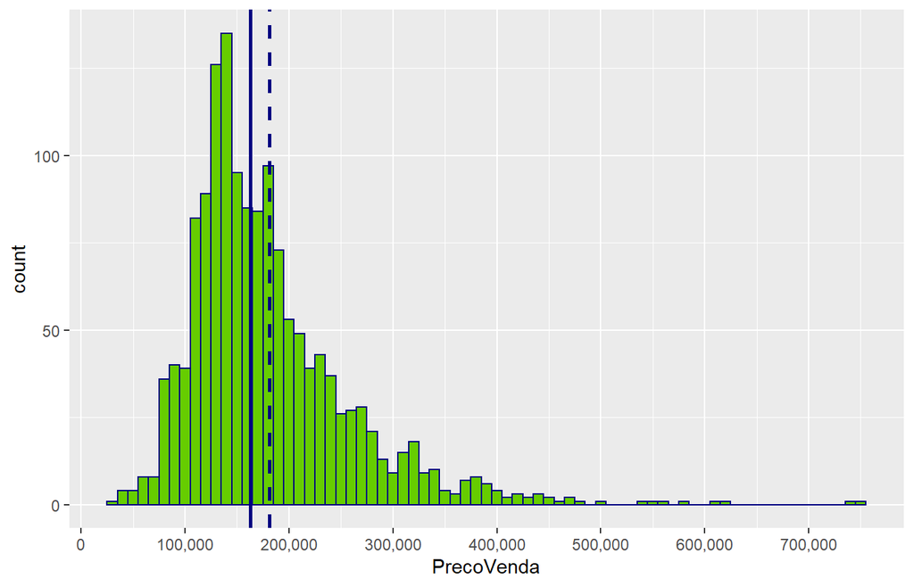

```r
ggplot(data=todas[!is.na(todas$PrecoVenda),], aes(x=PrecoVenda)) +
  geom_histogram(color="navy", fill="chartreuse3", binwidth = 10000) +
  scale_x_continuous(breaks= seq(0, 800000, by=100000), labels = comma) +
  geom_vline(aes(xintercept=mean(PrecoVenda)), color="navy", linetype="dashed", size=1)+
  geom_vline(aes(xintercept=median(PrecoVenda)), color="navy", size=1)
```

```r
summary(todas$PrecoVenda)
```

```
##    Min. 1st Qu.  Median    Mean 3rd Qu.    Max.    NA's
##   34900  129975  163000  180921  214000  755000    1459
```

Percebe-se claramente uma distribuição não-uniforme com assimetria > 0 (cauda direita). Será necessario normalização.

## 4.2 Correlação entre as variáveis numéricas e o preço de venda

Nesta etapa foram separadas as variáveis numéricas, calculadas suas correlações com a variável alvo (Coeficiente de correlação de Pearson) e plotadas somente as variáveis que possuem correlação maior que 0,5 (positiva ou negativa).

+1 ou -1 representam correlações perfeitas, seja diretamente proporcional (+) ou inversamente proporcional (-1)

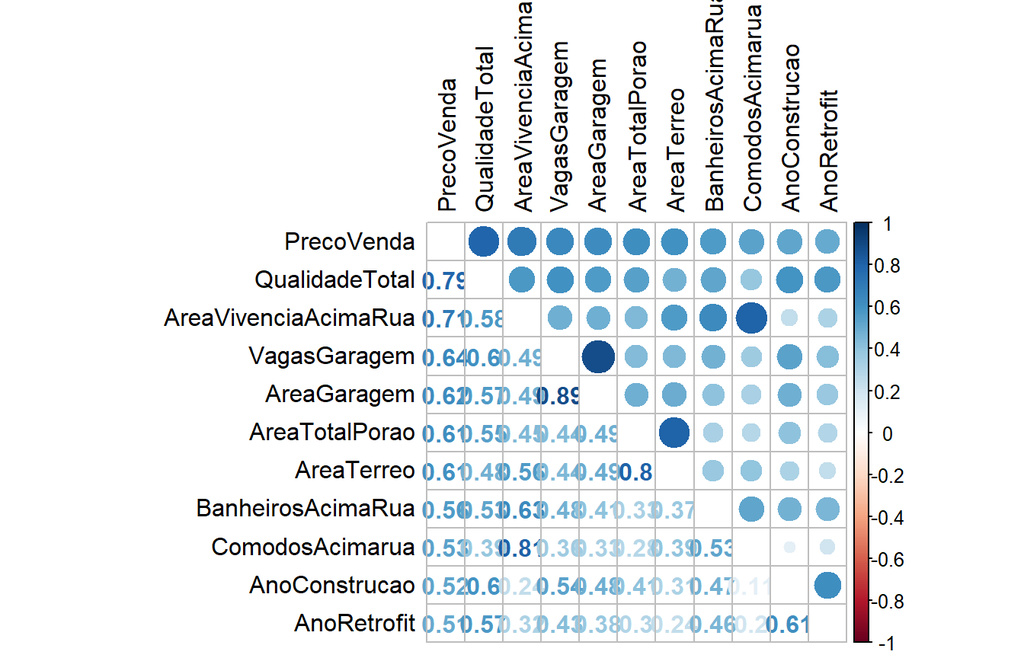

```r
numericVars <- which(sapply(todas, is.numeric))
numericVarNames <- names(numericVars) # salvando os titulos como vetor
all_numericas <- todas[, numericVars] # subset somente das numéricas
cor_numericas <- cor(all_numericas, use="pairwise.complete.obs") # correlações entre as numericas
cor_ordenada <- as.matrix(sort(cor_numericas[,'PrecoVenda'], decreasing = TRUE)) #ordenando de forma decrescente

# Selecionando as altas, retornando para a matriz e plotado
cor_alta <- names(which(apply(cor_ordenada, 1, function(x) abs(x)>0.5)))
cor_principaisnum <- cor_numericas[cor_alta, cor_alta]
corrplot.mixed(cor_principaisnum, tl.col="black", tl.pos = "lt")
```

A priori, entre as variáveis numéricas, observa-se que as variáveis com maior correlação com o preço de venda são: `Qualidade Total (acabamentos)`, `Área Privativa (em pés quadrados)` e `quantiade de vagas na garagem`. Contudo, neste momento é importante observar a altissima correlação de algumas variáveis entre si.

Pode-se perceber a alta correlação entre a `Área da Garagam` e a `Quantiade de vagas`, bem como `Área Privativa (AreaVivenciaAcimaRua)` e `Quantiade de Cômodos`. Estas relações são óbvias, porém dever haver uma atenção especial para evitar a `multicolinearidade` e consequentemente o comprometimento do algoritmo preditivo. Tais variáveis serão tratadas com mais detalhes na etapa de Feature Engineering.

Esta matriz é apenas uma visualização preliminar, após transformar algumas variáveis categóricas em numéricas a matriz será recalculada para mais variáveis. Além disso, como forma de determinar a importância de cada característica, a matriz é relativamente limitada. Mais à frente o estudo irá aplicar algoritmos avançados que consideram permutações aleatórias e erros associados para criar um ranking de importância. Logo, estas informações são apenas para se familiarizar com as informações fornecidas.

## 4.3 Visualizando a variável mais importante (até o momento) - Qualidade Total

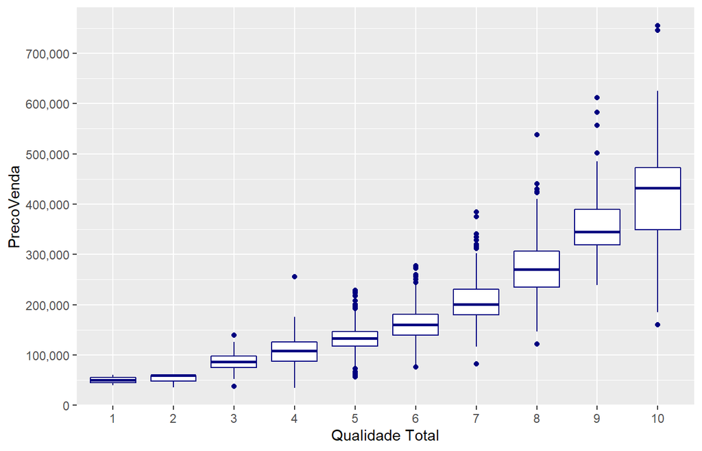

```r
ggplot(data=todas[!is.na(todas$PrecoVenda),], aes(x=factor(QualidadeTotal), y=PrecoVenda))+
  geom_boxplot(col='navy') + labs(x='Qualidade Total') +
  scale_y_continuous(breaks= seq(0, 800000, by=100000), labels = comma)
```

Percebe-se claramente a relação entre qualidade e preço de venda no que se aproxima de uma curva. Observa-se também que a distância ente o primeiro e o terceiro quartil aumenta para as casas com maior qualidade total, provavelmente influência de outras variáveis inexistentes nos demais imóveis.

## 4.4 Visualizando a segunda variável mais importante (até o momento) - Área Privativa

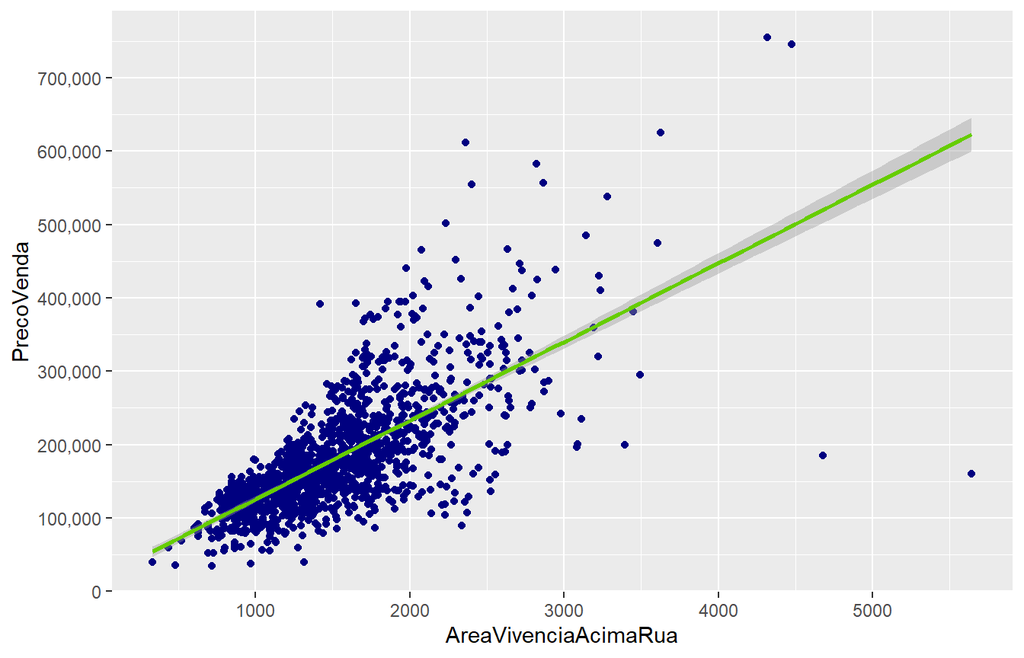

```r
ggplot(data=todas[!is.na(todas$PrecoVenda),], aes(x=AreaVivenciaAcimaRua, y=PrecoVenda))+
  geom_point(col='navy') + geom_smooth(method = "lm", color="chartreuse3", aes(group=1)) +
  scale_y_continuous(breaks= seq(0, 800000, by=100000), labels = comma)
```

Dois pontos se destacam com uma área privativa grande e preço muito baixo, bem como dois pontos também possuem área grande e valores muito altos. Uma opção é rotular estes pontos para recuperação dos dados.

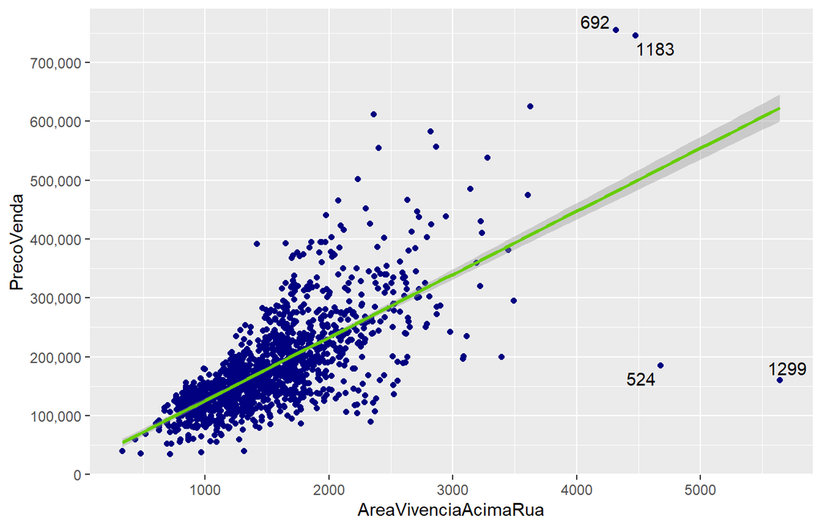

```r
ggplot(data=todas[!is.na(todas$PrecoVenda),], aes(x=AreaVivenciaAcimaRua, y=PrecoVenda))+
  geom_point(col='navy') + geom_smooth(method = "lm", color="chartreuse3", aes(group=1)) +
  scale_y_continuous(breaks= seq(0, 800000, by=100000), labels = comma)+
  geom_text_repel(aes(label = ifelse(todas$AreaVivenciaAcimaRua[!is.na(todas$PrecoVenda)]>4000, rownames(todas), '')))
```

Assim, pode-se recuperar estes 4 imóveis e proceder uma avaliação isolada pra investigação desta variação:

```r
kable(todas[c(524,692,1183,1299),]) %>%
  kableExtra::kable_styling() %>%
  kableExtra::scroll_box(width = "100%")
```

|  | Id | Classe | Zona | DimFrontal | AreaLote | TipoEstrada | TipoRua | RelevoLote | GreideLote | Instalacoes | ImplantacaoLote | Declive | Bairro | Proximidade1 | Proximidade2 | TipoHabitacao | Pavimentos | QualidadeTotal | CondicaoTotal | AnoConstrucao | AnoRetrofit | TipoCobertura | MaterialCobertura | Fachada1 | Fachada2 | TipoAlvenaria | AreaAlvenaria | QualidadeFachada | CondicaoFachada | … |
| --- | --- | --- | --- | --- | --- | --- | --- | --- | --- | --- | --- | --- | --- | --- | --- | --- | --- | --- | --- | --- | --- | --- | --- | --- | --- | --- | --- | --- | --- | --- |
| 524 | 524 | 60 | RL | 130 | 40094 | Pave | NA | IR1 | Bnk | AllPub | Inside | Gtl | Edwards | PosN | PosN | 1Fam | 2Story | 10 | 5 | 2007 | 2008 | Hip | CompShg | CemntBd | CmentBd | Stone | 762 | Ex | TA | … |
| 692 | 692 | 60 | RL | 104 | 21535 | Pave | NA | IR1 | Lvl | AllPub | Corner | Gtl | NoRidge | Norm | Norm | 1Fam | 2Story | 10 | 6 | 1994 | 1995 | Gable | WdShngl | HdBoard | HdBoard | BrkFace | 1170 | Ex | TA | … |
| 1183 | 1183 | 60 | RL | 160 | 15623 | Pave | NA | IR1 | Lvl | AllPub | Corner | Gtl | NoRidge | Norm | Norm | 1Fam | 2Story | 10 | 5 | 1996 | 1996 | Hip | CompShg | Wd Sdng | ImStucc | None | 0 | Gd | TA | … |
| 1299 | 1299 | 60 | RL | 313 | 63887 | Pave | NA | IR3 | Bnk | AllPub | Corner | Gtl | Edwards | Feedr | Norm | 1Fam | 2Story | 10 | 5 | 2008 | 2008 | Hip | ClyTile | Stucco | Stucco | Stone | 796 | Ex | TA | … |

Este estudo não se aprofundará neste tipo de análise (diagnóstica). Caso estas variáveis impactem como outliers, serão descartadas na etapa de Feature Engineering. Já visualização das demais variáveis será feita na próxima etapa, em conjunto com o tratamento dos dados missing e de forma mais detalhada também na etapa de Feature Engineering.

# 5 Dados Missing (NA)

O tratamento de dados missing é uma etapa fundamental para não comprometer análises futuras, além de obrigatória para a modelagem do algoritmo preditivo. Para tal, existem considerações importante a se fazer e diferentes decisões que vão variar de acordo com quem está tratando os dados.

Importante lembrar que o valor `NA` não é propriamente um valor, e sim uma sintaxe da linguagem que representa um dado faltante. Por conta da expressão em português `Não Aplicável` existe essa confusão, mas para o software `NA` indica `Not Available`. Por isso, precisam ser substituido por alguma informação, nem que seja `não possui`, `0`, `Não Aplicável`, etc.

Eventualmente, vão existir colunas no conjunto de dados que a presença do `NA` é esperada, pois é assim que os dados saem da ferramenta transacional (geralmente um campo não-obrigatório que não foi preenchido). E no caso deste conjunto, na própria documentação são informados os significados do valor `NA` de algumas variáveis categóricas. Geralmente “não possui”.

Contudo, em variáveis numéricas onde o valor `zero` significa não possui, o valor `NA` deve ser tratado com mais cautela. E isto precisa ocorrer caso a caso, podendo substituí-los por `zero` quando houver evidências (geralmente em outras variáveis correlatas), pela média das outras observações, mediana, valor mais comum, proporção de outra variável, eliminação da observação entre outras opções. Por este motivo esta análise é a mais extensa e criteriosa do estudo.

## 5.1 Quantidade de valores NA em cada coluna

Vale ressaltar que as 1459 linhas do conjunto de teste estão com valor `NA` na coluna `PrecoVenda` que foi criada para poder unir os dois conjuntos, estão é esperado que a coluna PrecoVenda tenha, pelo menos, 1459 `NAs`. Esta coluna não precisa de tratamento pois os conjuntos serão separados novamente no momento da modelagem.

```r
NAcol <- which(colSums(is.na(todas)) > 0) # quais colunas tem NA
sort(colSums(sapply(todas[NAcol], is.na)), decreasing = TRUE) # somando quantidade de NA e ordenando
```

```
##       QualiPiscina        OutrosItens            TipoRua         QualiCerca
##               2909               2814               2721               2348
##         PrecoVenda   QualidadeLareira         DimFrontal         AnoGaragem
##               1459               1420                486                159
##  AcabamentoGaragem       QualiGaragem    CondicaoGaragem        TipoGaragem
##                159                159                159                157
##      CondicaoPorao     ExposicaoPorao        AlturaPorao RevestimentoPorao2
##                 82                 82                 81                 80
## RevestimentoPorao1      TipoAlvenaria      AreaAlvenaria               Zona
##                 79                 24                 23                  4
##        Instalacoes     BanheirosPorao        LavaboPorao          Descontos
##                  2                  2                  2                  2
##           Fachada1           Fachada2  AreaPoraoAcabado1  AreaPoraoAcabado2
##                  1                  1                  1                  1
##    AreaPoraoInacab     AreaTotalPorao    SistemaEletrico   QualidadeCozinha
##                  1                  1                  1                  1
##       VagasGaragem        AreaGaragem          TipoVenda
##                  1                  1                  1
```

```r
cat('Existem', length(NAcol), 'colunas com valores missing')
```

```
## Existem 35 colunas com valores missing
```

Como esperado, 1459 `NAs` na coluna PrecoVenda, o que é ótimo, pois não existem NAs onde era para ter valor (conjunto de treinamento).

Algumas colunas chamam a atençao, como o tipo de garagem de possui 157 `NAs` enquanto as outras relacionadas à garagem possuem 159, mas serão avaliados um a um.

Esta etapa aproveita para converter algumas variáveis em texto (char) em categorias (factors). Neste sentido, quando existir ordinalidade entre as categorias como: péssimo, ruim, regular etc serão atribuídos valores numéricos, possibilitando cálculos.

### 5.1.1 Variáveis relacionadas à piscina

Segundo a documentação, para esta variável, os valores `NA` signifcam `"None"` ou `"Não existe"`.

```r
todas$QualiPiscina[is.na(todas$QualiPiscina)] <- 'None'
```

As categorias da variável são claramente ordinais: de péssimo a excelente. Como esta classificação é repetida para outras variáveis, será criado um vetor `Qualidades`, relacionando o texto a um número e facilitando as transformações futuras.

```r
Qualidades <- c('None' = 0, 'Po' = 1, 'Fa' = 2, 'TA' = 3, 'Gd' = 4, 'Ex' = 5) # criação do vetor Qualidades
todas$QualiPiscina <- as.integer(revalue(todas$QualiPiscina, Qualidades)) # atribuição de valores
table(todas$QualiPiscina) # contagem
```

```
##
##    0    2    4    5
## 2909    2    4    4
```

Nesta etapa é importante avaliar a relação com outras variáveis, por exemplo: área da piscina para encontrar inconsistências, pois não pode haver piscinas com `zero` na variável Qualidade da Piscina e ao mesmo tempo área da piscina diferente de zero. Para verificar estas condições será puxado os imóveis com `Área Piscina > 0` e suas respectivas Qualidades atribuidas:

```r
arrange(todas[todas$AreaPiscina>0, c( 'Id', 'AreaPiscina', 'QualiPiscina')], QualiPiscina)
```

```
##      Id AreaPiscina QualiPiscina
## 1  2421         368            0
## 2  2504         444            0
## 3  2600         561            0
## 4   811         648            2
## 5  1387         519            2
## 6  1171         576            4
## 7  1299         480            4
## 8  1424         738            4
## 9  2711         800            4
## 10  198         512            5
## 11 1183         555            5
## 12 1975         144            5
## 13 2574         228            5
```

Observa-se que três casas possuem `QualiPiscina = 0` e possuem `Área de piscina > 0`, certamente eram valores que vieram `NA` mas eram pra estar preenchidos com a qualidade. Para substituição dos valores uma opção é econtrar uma relação (ainda que visual) com outras variáveis. Será testado com a variável Qualidade Total.

```r
arrange(todas[todas$AreaPiscina>0, c('Id', 'AreaPiscina', 'QualiPiscina', 'QualidadeTotal')], QualiPiscina)
```

```
##      Id AreaPiscina QualiPiscina QualidadeTotal
## 1  2421         368            0              4
## 2  2504         444            0              6
## 3  2600         561            0              3
## 4   811         648            2              6
## 5  1387         519            2              7
## 6  1171         576            4              6
## 7  1299         480            4             10
## 8  1424         738            4              6
## 9  2711         800            4              7
## 10  198         512            5              8
## 11 1183         555            5             10
## 12 1975         144            5             10
## 13 2574         228            5              8
```

```r
todas$QualiPiscina[2421] <- 2
todas$QualiPiscina[2504] <- 3
todas$QualiPiscina[2600] <- 1
```

### 5.1.2 Outros Itens

A variável `Outros Itens` diz respeito a demais sistemas do imóvel não contabilizados como elevadores, quadra de tenis e outros. Tal qual `QualiPiscina`, segundo a documentação, valores `NA` significam `None` e significa que o imóvel não possui estes outros itens.

```r
todas$OutrosItens[is.na(todas$OutrosItens)] <- 'None'
```

Como não existe ordinalidade evidente entre as categorias (como péssimo, ruim, regular, etc), será observado a relação com o `Preço de Venda`.

obs.: o gráfico plota uma barra com a *mediana* no Preco de Venda para cada categoria da variável, um ponto com a *média* do Preço de Venda e uma contagem numérica dos imóveis de cada categoria.

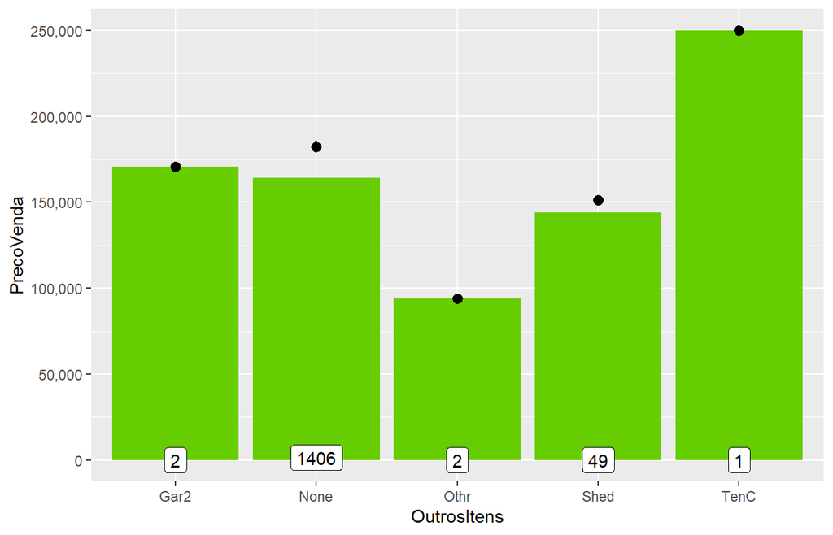

```r
ggplot(todas[!is.na(todas$PrecoVenda),], aes(x=OutrosItens, y=PrecoVenda)) +
  geom_bar(stat="summary", fun="median", fill='chartreuse3') +
  stat_summary(fun="mean")+
  scale_y_continuous(breaks= seq(0, 800000, by=50000), labels = comma) +
  geom_label(stat = "count", aes(label = ..count.., y = ..count..))
```

Como não existe uma ordem clara entre as categorias, não há como relacioná-las à variáveis numéricas e será apenas transformada em `fator`, que é o tipo de sintaxe referente a categorias.

```r
todas$OutrosItens <- as.factor(todas$OutrosItens)

table(todas$OutrosItens)
```

```
##
## Gar2 None Othr Shed TenC
##    5 2814    4   95    1
```

### 5.1.3 Tipo de rua

Similar aos anteriores, o valor NA significa `None`.

```r
todas$TipoRua[is.na(todas$TipoRua)] <- 'None'
```

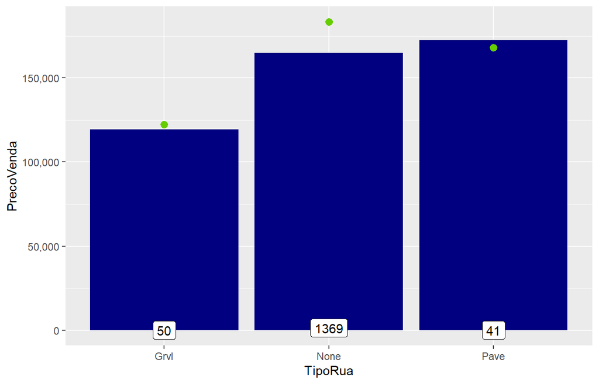

```r
ggplot(todas[!is.na(todas$PrecoVenda),], aes(x=TipoRua, y=PrecoVenda)) +
  geom_bar(stat="summary", fun="median", fill='navyblue') +
  stat_summary(fun="mean", color= "chartreuse3")+
  scale_y_continuous(breaks= seq(0, 200000, by=50000), labels = comma) +
  geom_label(stat = "count", aes(label = ..count.., y = ..count..))
```

Também não será transformada em variável numérica.

```r
todas$TipoRua <- as.factor(todas$TipoRua)

table(todas$TipoRua)
```

```
##
## Grvl None Pave
##  120 2721   78
```

### 5.1.4 Qualidade da cerca

Similar aos anteriores, o valor NA significa `None`.

```r
todas$QualiCerca[is.na(todas$QualiCerca)] <- 'None'
```

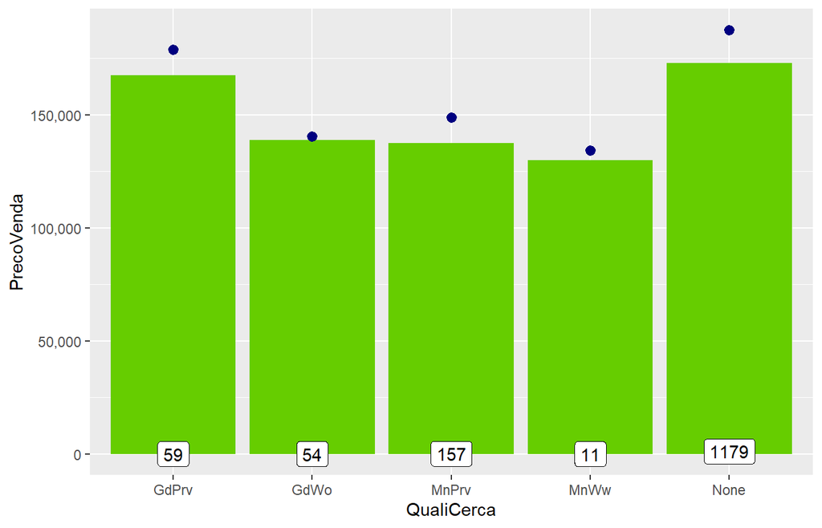

```r
ggplot(todas[!is.na(todas$PrecoVenda),], aes(x=QualiCerca, y=PrecoVenda)) +
  geom_bar(stat="summary", fun="median", fill='chartreuse3') +
  stat_summary(fun="mean", color="navy")+
  scale_y_continuous(breaks= seq(0, 200000, by=50000), labels = comma) +
  geom_label(stat = "count", aes(label = ..count.., y = ..count..))
```

Talvez, mas não óbvio.

```r
todas[!is.na(todas$PrecoVenda),] %>% group_by(QualiCerca) %>%
  summarise(mediana = median(PrecoVenda), media = mean(PrecoVenda), counts=n())
```

```
## # A tibble: 5 x 4
##   QualiCerca mediana   media counts
##   <chr>        <dbl>   <dbl>  <int>
## 1 GdPrv       167500 178927.     59
## 2 GdWo        138750 140379.     54
## 3 MnPrv       137450 148751.    157
## 4 MnWw        130000 134286.     11
## 5 None        173000 187597.   1179
```

Não há variações claras de acordo com a categoria. Portanto, não serão transformadas em numéricas.

```r
todas$QualiCerca <- as.factor(todas$QualiCerca)
table(todas$QualiCerca)
```

```
##
## GdPrv  GdWo MnPrv  MnWw  None
##   118   112   329    12  2348
```

### 5.1.5 Variáveis relacionadas a lareira

#### 5.1.5.1 Qualidade

Similar aos anteriores, o valor NA significa `None`.

```r
todas$QualidadeLareira[is.na(todas$QualidadeLareira)] <- 'None'

table(todas$QualidadeLareira)
```

```
##
##   Ex   Fa   Gd None   Po   TA
##   43   74  744 1420   46  592
```

As categorias são as mesmas já tratadas para qualidade da piscina e, desta forma, serão tranformadas em numéricas.

```r
todas$QualidadeLareira <- as.integer(revalue(todas$QualidadeLareira, Qualidades))

table(todas$QualidadeLareira)
```

```
##
##    0    1    2    3    4    5
## 1420   46   74  592  744   43
```

### 5.1.6 Variáveis relacionadas ao lote

#### 5.1.6.1 Dimensão frontal

Esta é uma variável numérica, o que significa não que existe uma definição para o valor `NA`, é apenas um valor não preenchido. Assim, foi decidido substituir os valores NA pela mediana dos valores de Dimensão Frontal no mesmo bairro daquele imóvel.

A plotagem abaixo mostra que os valores de dimensão frontal varia consideravelmente para cada bairro.

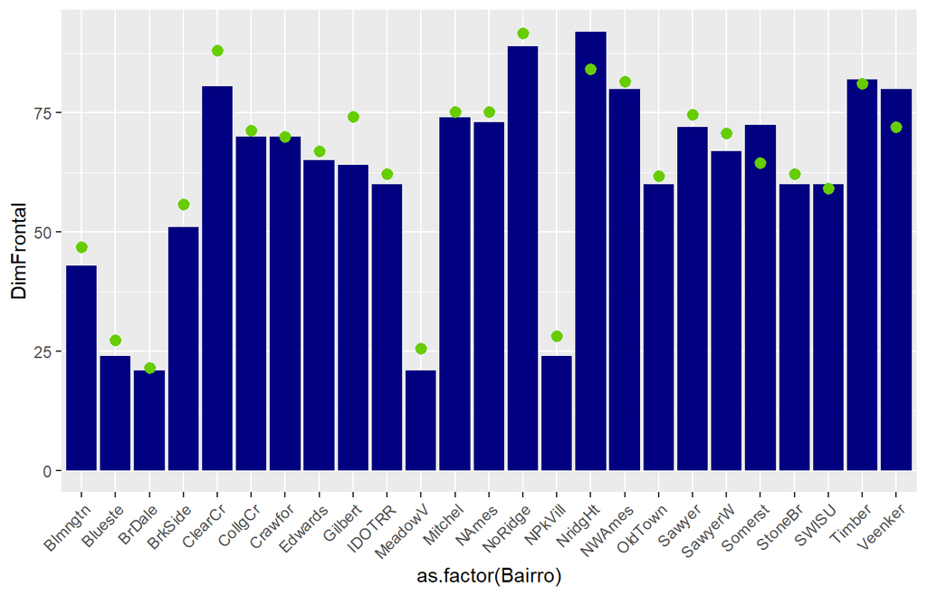

```r
ggplot(todas[!is.na(todas$DimFrontal),], aes(x=as.factor(Bairro), y=DimFrontal)) +
  geom_bar(stat='summary', fun = "median", fill='navyblue') +
  stat_summary(fun="mean", color="chartreuse3")+
  theme(axis.text.x = element_text(angle = 45, hjust = 1))
```

```r
for (i in 1:nrow(todas)){
  if(is.na(todas$DimFrontal[i])){
    todas$DimFrontal[i] <- as.integer(median(todas$DimFrontal[todas$Bairro==todas$Bairro[i]], na.rm=TRUE))
  }
}

summary(todas$DimFrontal)
```

```
##    Min. 1st Qu.  Median    Mean 3rd Qu.    Max.
##   21.00   60.00   70.00   69.54   80.00  313.00
```

#### 5.1.6.2 Relevo

As classes de relevo, apesar de não possuirem `NAs`, são ordinárias e serão transformadas em numéricas.

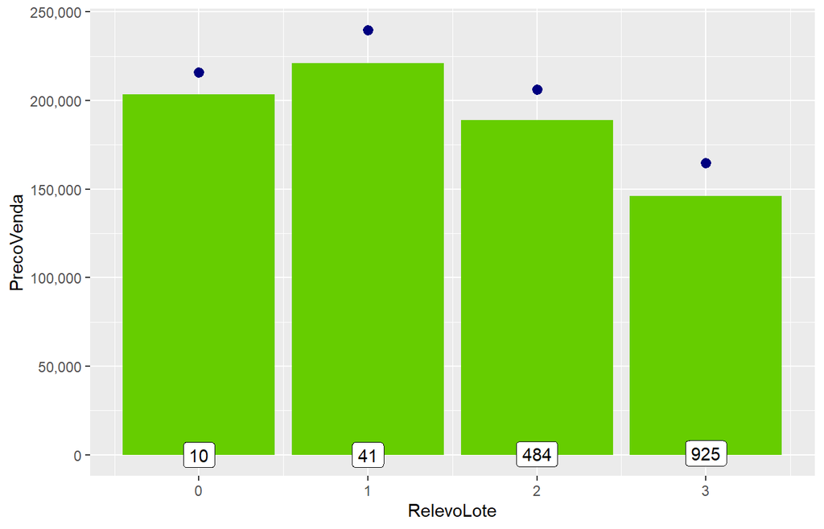

```r
todas$RelevoLote <- as.integer(revalue(todas$RelevoLote, c('IR3'=0,'IR2'=1, 'IR1'=2,'Reg'=3)))

ggplot(todas[!is.na(todas$PrecoVenda),], aes(x=RelevoLote, y=PrecoVenda)) +
  geom_bar(stat="summary", fun="median", fill='chartreuse3') +
  stat_summary(fun="mean", color="navyblue")+
  scale_y_continuous(breaks= seq(0, 500000, by=50000), labels = comma) +
  scale_x_continuous(breaks= seq(0, 500000, by=1)) +
  geom_label(stat = "count", aes(label = ..count.., y = ..count..))
```

```r
table(todas$RelevoLote)
```

```
##
##    0    1    2    3
##   16   76  968 1859
```

#### 5.1.6.3 Implantação

A implantação não parece ordinal, nem pelas classes nem pela distribuição. Portanto, só sera convertido em fator

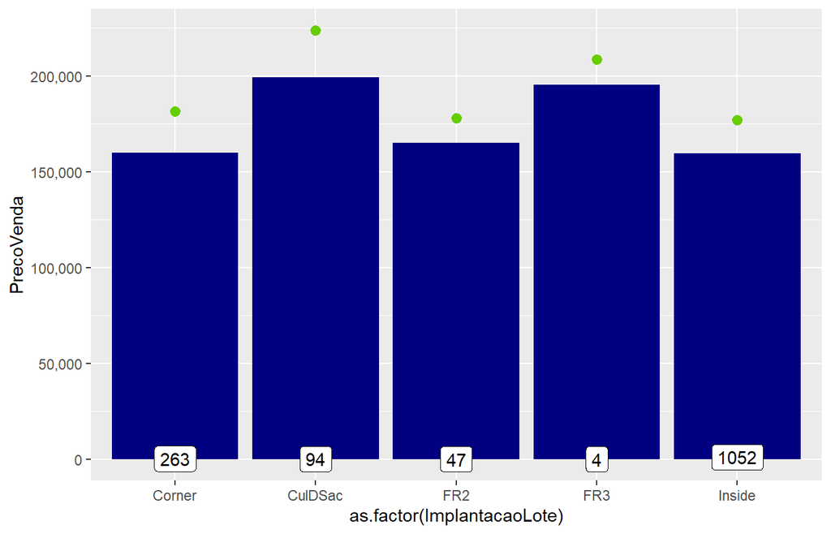

```r
ggplot(todas[!is.na(todas$PrecoVenda),], aes(x=as.factor(ImplantacaoLote), y=PrecoVenda)) +
  geom_bar(stat="summary", fun="median", fill='navyblue') +
  stat_summary(fun="mean",color="chartreuse3")+
  scale_y_continuous(breaks= seq(0, 800000, by=50000), labels = comma) +
  geom_label(stat = "count", aes(label = ..count.., y = ..count..))
```

```r
todas$ImplantacaoLote <- as.factor(todas$ImplantacaoLote)
table(todas$ImplantacaoLote)
```

```
##
##  Corner CulDSac     FR2     FR3  Inside
##     511     176      85      14    2133
```

### 5.1.7 Variáveis relacionadas à garagens

#### 5.1.7.1 Ano Garagem

Os `NAs` serão substítuidos pelo ano de construção do imóvel

```r
todas$AnoGaragem[is.na(todas$AnoGaragem)] <- todas$AnoConstrucao[is.na(todas$AnoGaragem)]
```

```r
kable(todas[!is.na(todas$TipoGaragem) & is.na(todas$CondicaoGaragem),
      c('AnoGaragem', 'AcabamentoGaragem', 'TipoGaragem', 'QualiGaragem', 'CondicaoGaragem', 'AreaGaragem', 'VagasGaragem')])
```

|  | AnoGaragem | AcabamentoGaragem | TipoGaragem | QualiGaragem | CondicaoGaragem | AreaGaragem | VagasGaragem |
| --- | --- | --- | --- | --- | --- | --- | --- |
| 2127 | 1910 | NA | Detchd | NA | NA | 360 | 1 |
| 2577 | 1923 | NA | Detchd | NA | NA | NA | NA |

```r
todas$CondicaoGaragem[2127] <- names(sort(-table(todas$CondicaoGaragem)))[1]
todas$QualiGaragem[2127] <- names(sort(-table(todas$QualiGaragem)))[1]
todas$AcabamentoGaragem[2127] <- names(sort(-table(todas$AcabamentoGaragem)))[1]
```

Ja o imóvel 2577 aparentemente não possui garagem, e o tipo está preenchido incorretamente. Será atribuído NA ao Tipo e 0 à área e às vagas.

```r
todas$TipoGaragem[2577] <- NA
todas$VagasGaragem[2577] <- 0
todas$AreaGaragem[2577] <- 0
```

#### 5.1.7.2 Tipo de garagem

O tipo de garagem não parece ser ordinário, não será convertido em variável numérica.

```r
todas$TipoGaragem[is.na(todas$TipoGaragem)] <- 'No Garage'
```

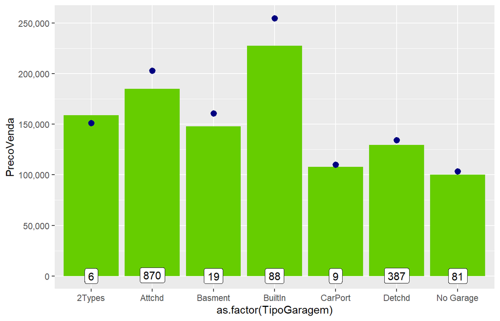

```r
ggplot(todas[!is.na(todas$PrecoVenda),], aes(x=as.factor(TipoGaragem), y=PrecoVenda)) +
  geom_bar(stat="summary", fun="median", fill='chartreuse3') +
  stat_summary(fun="mean", color="navyblue")+
  scale_y_continuous(breaks= seq(0, 800000, by=50000), labels = comma) +
  geom_label(stat = "count", aes(label = ..count.., y = ..count..))
```

```r
todas$TipoGaragem[is.na(todas$TipoGaragem)] <- 'No Garage'
todas$TipoGaragem <- as.factor(todas$TipoGaragem)
table(todas$TipoGaragem)
```

```
##
##    2Types    Attchd   Basment   BuiltIn   CarPort    Detchd No Garage
##        23      1723        36       186        15       778       158
```

#### 5.1.7.3 Acabamento, qualidade e condição

As três variáveis funcionam da mesma forma: `NA = "None"` e os valores podem ser convertidos em numéricos.

Acabamento

```r
todas$AcabamentoGaragem[is.na(todas$AcabamentoGaragem)] <- 'No Garage'
acabamentos <- c('No Garage'=0,'Unf'=1,'RFn'=2,'Fin'=3)
todas$AcabamentoGaragem <- as.integer(revalue(todas$AcabamentoGaragem, acabamentos))
table(todas$AcabamentoGaragem)
```

```
##
##    0    1    2    3
##  158 1231  811  719
```

Qualidade

```r
todas$QualiGaragem[is.na(todas$QualiGaragem)] <- 'None'
todas$QualiGaragem <- as.integer(revalue(todas$QualiGaragem, Qualidades))
table(todas$QualiGaragem)
```

```
##
##    0    1    2    3    4    5
##  158    5  124 2605   24    3
```

Condição

```r
todas$CondicaoGaragem[is.na(todas$CondicaoGaragem)] <- 'None'
todas$CondicaoGaragem <- as.integer(revalue(todas$CondicaoGaragem, Qualidades))
table(todas$CondicaoGaragem)
```

```
##
##    0    1    2    3    4    5
##  158   14   74 2655   15    3
```

### 5.1.8 Variáveis relacionadas ao porão

#### 5.1.8.1 Condição, Exposição, Altura e Revestimentos.

```r
NAcol <- which(colSums(is.na(todas)) > 0) # quais colunas tem NA
sort(colSums(sapply(todas[NAcol], is.na)), decreasing = TRUE) # somando quantidade de NA e ordenando
```

```
##         PrecoVenda      CondicaoPorao     ExposicaoPorao        AlturaPorao
##               1459                 82                 82                 81
## RevestimentoPorao2 RevestimentoPorao1      TipoAlvenaria      AreaAlvenaria
##                 80                 79                 24                 23
##               Zona        Instalacoes     BanheirosPorao        LavaboPorao
##                  4                  2                  2                  2
##          Descontos           Fachada1           Fachada2  AreaPoraoAcabado1
##                  2                  1                  1                  1
##  AreaPoraoAcabado2    AreaPoraoInacab     AreaTotalPorao    SistemaEletrico
##                  1                  1                  1                  1
##   QualidadeCozinha          TipoVenda
##                  1                  1
```

Primeiro, será verificado se os 79 `NAs` da variável `RevestimentoPorao1` também são `NAs` nas outras 4 variáveis. A linha de código a seguir informa a quantidade de valores que são NA, simultaneamente, nas 5 variáveis listadas (`CondicaoPorao`, `ExposicaoPorao`, `AlturaPorao`, `RevestimentoPorao1` e `RevestimentoPorao2`):

```r
length(which(is.na(todas$CondicaoPorao) & is.na(todas$ExposicaoPorao) & is.na(todas$AlturaPorao) &
              is.na(todas$RevestimentoPorao1) & is.na(todas$RevestimentoPorao2)))
```

```
## [1] 79
```

Isto indica que, provavelmente, existam 79 imóveis sem porão acabado e nas demais variáveis 1, 2 ou 3 `NAs` a serem corrigidos com investigação mais detalhada.

```r
kable(todas[!is.na(todas$RevestimentoPorao1) &
        (is.na(todas$CondicaoPorao)|is.na(todas$ExposicaoPorao)|is.na(todas$AlturaPorao)|is.na(todas$RevestimentoPorao2)),
    c('CondicaoPorao', 'ExposicaoPorao', 'AlturaPorao', 'RevestimentoPorao2', 'RevestimentoPorao1')]) %>%
  kableExtra::kable_styling() %>%
  kableExtra::scroll_box(width = "100%")
```

|  | CondicaoPorao | ExposicaoPorao | AlturaPorao | RevestimentoPorao2 | RevestimentoPorao1 |
| --- | --- | --- | --- | --- | --- |
| 333 | TA | No | Gd | NA | GLQ |
| 949 | TA | NA | Gd | Unf | Unf |
| 1488 | TA | NA | Gd | Unf | Unf |
| 2041 | NA | Mn | Gd | Rec | GLQ |
| 2186 | NA | No | TA | Unf | BLQ |
| 2218 | Fa | No | NA | Unf | Unf |
| 2219 | TA | No | NA | Unf | Unf |
| 2349 | TA | NA | Gd | Unf | Unf |
| 2525 | NA | Av | TA | Unf | ALQ |

Aqui vemos que os `NAs` das outras 4 variáveis estão espalhados e não são no mesmo imóvel. Caso estivessem, provavelmente a variável RevestimentoPorao1 estaria preenchida quando era para ser `NA` (sem porão).

Neste caso, cada variável sera substituida pelo valor mais comum (moda) do seu respectivo bairro.

```r
getmode <- function(v) {
  uniqv <- unique(v)
  uniqv[which.max(tabulate(match(v, uniqv)))]
}

todas$RevestimentoPorao2[333] <- getmode(todas$RevestimentoPorao2[todas$Bairro==todas$Bairro[333]])
todas$AlturaPorao[2218] <- getmode(todas$AlturaPorao[todas$Bairro==todas$Bairro[2218]])
todas$AlturaPorao[2219] <- getmode(todas$AlturaPorao[todas$Bairro==todas$Bairro[2219]])
todas$ExposicaoPorao[949] <- getmode(todas$ExposicaoPorao[todas$Bairro==todas$Bairro[949]])
todas$ExposicaoPorao[1488] <- getmode(todas$ExposicaoPorao[todas$Bairro==todas$Bairro[1488]])
todas$ExposicaoPorao[2349] <- getmode(todas$ExposicaoPorao[todas$Bairro==todas$Bairro[2349]])
todas$CondicaoPorao[2041] <- getmode(todas$CondicaoPorao[todas$Bairro==todas$Bairro[2041]])
todas$CondicaoPorao[2186] <- getmode(todas$CondicaoPorao[todas$Bairro==todas$Bairro[2186]])
todas$CondicaoPorao[2525] <- getmode(todas$CondicaoPorao[todas$Bairro==todas$Bairro[2525]])
```

Para conferir, será atualizada a tabela acima. O esperado e que não encontre linhas com valores `NA` em nenhuma das 5 variáveis:

```r
todas[!is.na(todas$RevestimentoPorao1) &
        (is.na(todas$CondicaoPorao)|is.na(todas$ExposicaoPorao)|is.na(todas$AlturaPorao)|is.na(todas$RevestimentoPorao2)),
    c('CondicaoPorao', 'ExposicaoPorao', 'AlturaPorao', 'RevestimentoPorao2', 'RevestimentoPorao1')]
```

```
## [1] CondicaoPorao      ExposicaoPorao     AlturaPorao        RevestimentoPorao2
## [5] RevestimentoPorao1
## <0 rows> (or 0-length row.names)
```

Todas as variáeis acima, os `NAs` significam `None` conforme a documentação do conjunto de dados além de possuírem ordinalidade nas suas categorias, sendo assim transformadas em variáveis numéricas.

```r
todas$AlturaPorao[is.na(todas$AlturaPorao)] <- 'None'
table(todas$AlturaPorao)
```

```
##
##   Ex   Fa   Gd None   TA
##  258   88 1209   79 1285
```

```r
todas$AlturaPorao <- as.integer(revalue(todas$AlturaPorao, Qualidades))

todas$CondicaoPorao[is.na(todas$CondicaoPorao)] <- 'None'
table(todas$CondicaoPorao)
```

```
##
##   Fa   Gd None   Po   TA
##  104  122   79    5 2609
```

```r
todas$CondicaoPorao <- as.integer(revalue(todas$CondicaoPorao, Qualidades))

todas$ExposicaoPorao[is.na(todas$ExposicaoPorao)] <- 'None'
table(todas$ExposicaoPorao)
```

```
##
##   Av   Gd   Mn   No None
##  418  276  239 1907   79
```

```r
todas$ExposicaoPorao <- as.integer(revalue(todas$ExposicaoPorao, c('None'=0, 'No'=1, 'Mn'=2, 'Av'=3, 'Gd'=4)))

todas$RevestimentoPorao1[is.na(todas$RevestimentoPorao1)] <- 'None'
table(todas$RevestimentoPorao1)
```

```
##
##  ALQ  BLQ  GLQ  LwQ None  Rec  Unf
##  429  269  849  154   79  288  851
```

```r
todas$RevestimentoPorao1 <- as.integer(revalue(todas$RevestimentoPorao1,
                                               c('None'=0, 'Unf'=1, 'LwQ'=2, 'Rec'=3, 'BLQ'=4, 'ALQ'=5, 'GLQ'=6)))

todas$RevestimentoPorao2[is.na(todas$RevestimentoPorao2)] <- 'None'
table(todas$RevestimentoPorao2)
```

```
##
##  ALQ  BLQ  GLQ  LwQ None  Rec  Unf
##   52   68   34   87   79  105 2494
```

```r
todas$RevestimentoPorao2 <- as.integer(revalue(todas$RevestimentoPorao2,
                                               c('None'=0, 'Unf'=1, 'LwQ'=2, 'Rec'=3, 'BLQ'=4, 'ALQ'=5, 'GLQ'=6)))
```

#### 5.1.8.2 Banheiros, Lavabo, Area Acabada, Inacabada e Area Total

Percebe-se que todos os `NAs` estão apenas em 2 imóveis, e que as demais áreas são `0`. Sendo assim, por lógica, os `NAs` também eram para ser `0`.

```r
todas[is.na(todas$BanheirosPorao)|is.na(todas$LavaboPorao)|is.na(todas$AreaPoraoAcabado1)|is.na(todas$AreaPoraoAcabado2)
      |is.na(todas$AreaPoraoInacab)|is.na(todas$AreaTotalPorao) & todas$AlturaPorao,
      c('BanheirosPorao', 'LavaboPorao', 'AreaPoraoAcabado1', 'AreaPoraoAcabado2', 'AreaPoraoInacab',
        'AreaTotalPorao', 'AlturaPorao')]
```

```
##      BanheirosPorao LavaboPorao AreaPoraoAcabado1 AreaPoraoAcabado2
## 2121             NA          NA                NA                NA
## 2189             NA          NA                 0                 0
##      AreaPoraoInacab AreaTotalPorao AlturaPorao
## 2121              NA             NA           0
## 2189               0              0           0
```

```r
table(todas$BanheirosPorao)
```

```
##
##    0    1    2    3
## 1705 1172   38    2
```

```r
todas$BanheirosPorao[is.na(todas$BanheirosPorao)] <- 0

table(todas$LavaboPorao)
```

```
##
##    0    1    2
## 2742  171    4
```

```r
todas$LavaboPorao[is.na(todas$LavaboPorao)] <- 0

todas$AreaPoraoAcabado1[is.na(todas$AreaPoraoAcabado1)] <- 0
todas$AreaPoraoAcabado2[is.na(todas$AreaPoraoAcabado2)] <- 0
todas$AreaPoraoInacab[is.na(todas$AreaPoraoInacab)] <- 0
todas$AreaTotalPorao[is.na(todas$AreaTotalPorao)] <- 0
```

### 5.1.9 Alvenaria

Da mesma forma, será verificado se os 23 `NAs` da variável `Area` também são `NAs` na variável `Tipo`.

```r
length(which(is.na(todas$TipoAlvenaria) & is.na(todas$AreaAlvenaria)))
```

```
## [1] 23
```

Sim. Portanto, o valor `NA` “excedente” do tipo será puxado

```r
todas[!is.na(todas$AreaAlvenaria) & (is.na(todas$TipoAlvenaria)),
      c('TipoAlvenaria', 'AreaAlvenaria')]
```

```
##      TipoAlvenaria AreaAlvenaria
## 2611          <NA>           198
```

#### 5.1.9.1 Tipo

O valor tem área preenchida normalmente e tipo `NA`, assim o tipo será substituido pelo segundo valor mais comum, pois o primeiro é `none`.

```r
todas$TipoAlvenaria[2611] <- names(sort(-table(todas$TipoAlvenaria)))[2]
```

Investigando os imóveis que possuem área de alvenaria acabada mas possui tipo `None`:

```r
todas[!is.na(todas$AreaAlvenaria) & todas$TipoAlvenaria=='None' & todas$AreaAlvenaria>0,
      c('TipoAlvenaria', 'AreaAlvenaria')]
```

```
##      TipoAlvenaria AreaAlvenaria
## 625           None           288
## 774           None             1
## 1231          None             1
## 1301          None           344
## 1335          None           312
## 1670          None           285
## 2453          None             1
```

Substituindo pelo segundo valor mais comum:

```r
for (i in 1:nrow(todas)){
  if(!is.na(todas$AreaAlvenaria[i]) & todas$TipoAlvenaria[i]=='None' & todas$AreaAlvenaria[i]>0){
    todas$TipoAlvenaria[i] <- names(sort(-table(todas$TipoAlvenaria)))[2]
  }
}
```

Aqui vale ressaltar que `None` é uma categoria da variável e ja veio no conjunto original de dados, os valores `NA` ainda continuam `NA`. Nas variáveis anteriores o valor que era para ser `None` vinha como `NA`.

Os 23 `NA` são casas que não possuem área de alvenaria acabada (dentro das opções apresentadas) e precisam ser transformados em `None`.

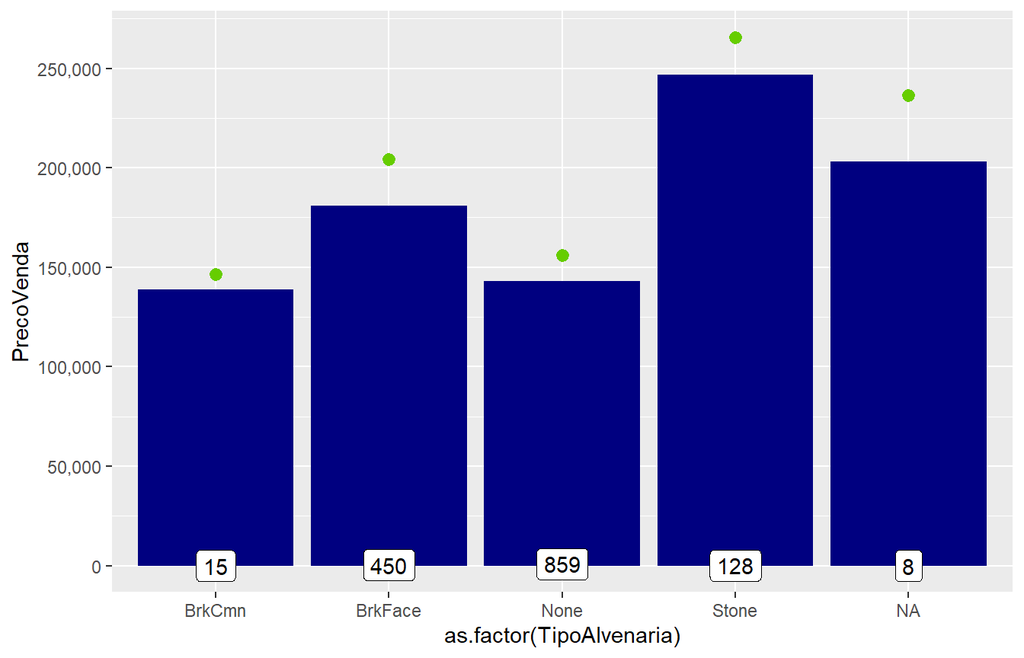

```r
ggplot(todas[!is.na(todas$PrecoVenda),], aes(x=as.factor(TipoAlvenaria), y=PrecoVenda)) +
  geom_bar(stat="summary", fun="median", fill='navyblue') +
  stat_summary(fun="mean", color= "chartreuse3")+
  scale_y_continuous(breaks= seq(0, 800000, by=50000), labels = comma) +
  geom_label(stat = "count", aes(label = ..count.., y = ..count..))
```

```r
todas$TipoAlvenaria[is.na(todas$TipoAlvenaria)] <- 'None'
table(todas$TipoAlvenaria)
```

```
##
##  BrkCmn BrkFace    None   Stone
##      25     887    1758     249
```

Atribuindo ordinalidade

```r
todas[!is.na(todas$PrecoVenda),] %>% group_by(TipoAlvenaria) %>%
  summarise(mediana = median(PrecoVenda), media = mean(PrecoVenda), counts=n())
```

```
## # A tibble: 4 x 4
##   TipoAlvenaria mediana   media counts
##   <chr>           <dbl>   <dbl>  <int>
## 1 BrkCmn         139000 146318.     15
## 2 BrkFace        181000 204239.    450
## 3 None           143000 156918.    867
## 4 Stone          246839 265584.    128
```

```r
todas$TipoAlvenaria <- as.integer(revalue(todas$TipoAlvenaria,
                                               c('None'=0, 'BrkCmn'=0, 'BrkFace'=1, 'Stone'=2)))
```

#### 5.1.9.2 Área

Os valores de área `NA` são zero.

```r
todas$AreaAlvenaria[is.na(todas$AreaAlvenaria)] <- 0
```

### 5.1.10 Zona

Será atribuida a zona mais comum no respectivo bairro

```r
for (i in 1:nrow(todas)){
  if(is.na(todas$Zona[i])){
    todas$Zona[i] <- getmode(todas$Zona[todas$Bairro==todas$Bairro[i]])
  }
}

todas$Zona<- as.factor(todas$Zona)

table(todas$Zona)
```

```
##
## C (all)      FV      RH      RL      RM
##      25     139      26    2266     463
```

### 5.1.11 Qualidade da cozinha

Atribuído valor mais comum e transformado em variável numérica.

```r
todas$QualidadeCozinha[is.na(todas$QualidadeCozinha)] <- names(sort(-table(todas$QualidadeCozinha)))[1]

table(todas$QualidadeCozinha)
```

```
##
##   Ex   Fa   Gd   TA
##  205   70 1151 1493
```

```r
todas$QualidadeCozinha <- as.integer(revalue(todas$QualidadeCozinha, Qualidades))

table(todas$QualidadeCozinha)
```

```
##
##    2    3    4    5
##   70 1493 1151  205
```

### 5.1.12 Instalações

```r
table(todas$Instalacoes)
```

```
##
## AllPub NoSeWa
##   2916      1
```

Observa-se que somente um imóvel não é `AllPub`. Logo, a variável não é significativa para análise nem para o algoritmo regressor e será descartada.

```r
todas$Instalacoes <- NULL
```

### 5.1.13 Descontos

Atribuído valor mais comum e transformado em variável numérica.

```r
todas$Descontos[is.na(todas$Descontos)] <- names(sort(-table(todas$Descontos)))[1]

table(todas$Descontos)
```

```
##
## Maj1 Maj2 Min1 Min2  Mod  Sev  Typ
##   19    9   65   70   35    2 2719
```

```r
todas$Descontos <- as.integer(revalue(todas$Descontos,
                                               c('Sal'=0, 'Sev'=1, 'Maj2'=2, 'Maj1'=3, 'Mod'=4, 'Min2'=5, 'Min1'=6, 'Typ'=7)))

table(todas$Descontos)
```

```
##
##    1    2    3    4    5    6    7
##    2    9   19   35   70   65 2719
```

### 5.1.14 Fachadas

Verificando de os `NAs` da `Fachada1` e `Fachada2` estão na mesma observação.

```r
todas[is.na(todas$Fachada1) & (is.na(todas$Fachada2)),
      c('Fachada1', 'Fachada2', 'QualidadeFachada')]
```

```
##      Fachada1 Fachada2 QualidadeFachada
## 2152     <NA>     <NA>               TA
```

Como possui qualidade, será atribuído o valor mais comum e a variável `Qualidade Fachada` convertida em numérico.

```r
todas$Fachada1[is.na(todas$Fachada1)] <- names(sort(-table(todas$Fachada1)))[1]
todas$Fachada2[is.na(todas$Fachada2)] <- names(sort(-table(todas$Fachada2)))[1]

todas$Fachada1 <- as.factor(todas$Fachada1)
todas$Fachada2 <- as.factor(todas$Fachada2)

todas$QualidadeFachada <- as.integer(revalue(todas$QualidadeFachada, Qualidades))
table(todas$QualidadeFachada)
```

```
##
##    2    3    4    5
##   35 1798  979  107
```

```r
todas$CondicaoFachada <- as.integer(revalue(todas$CondicaoFachada, Qualidades))
table(todas$CondicaoFachada)
```

```
##
##    1    2    3    4    5
##    3   67 2538  299   12
```

### 5.1.15 Sistema Elétrico

Atribuído o valor mais comum

```r
todas$SistemaEletrico[is.na(todas$SistemaEletrico)] <- names(sort(-table(todas$SistemaEletrico)))[1]
todas$SistemaEletrico <- as.factor(todas$SistemaEletrico)
table(todas$SistemaEletrico)
```

```
##
## FuseA FuseF FuseP   Mix SBrkr
##   188    50     8     1  2672
```

### 5.1.16 Tipo e Condição da venda

Atribuído o valor mais comum

```r
todas$TipoVenda[is.na(todas$TipoVenda)] <- names(sort(-table(todas$TipoVenda)))[1]
todas$TipoVenda <- as.factor(todas$TipoVenda)
table(todas$TipoVenda)
```

```
##
##   COD   Con ConLD ConLI ConLw   CWD   New   Oth    WD
##    87     5    26     9     8    12   239     7  2526
```

```r
todas$CondicaoVenda <- as.factor(todas$CondicaoVenda)
table(todas$CondicaoVenda)
```

```
##
## Abnorml AdjLand  Alloca  Family  Normal Partial
##     190      12      24      46    2402     245
```

### 5.1.17 Conferindo

Todos os valores `NA` foram investigados e substituídos.

```r
NAcol <- which(colSums(is.na(todas)) > 0) # quais colunas tem NA
sort(colSums(sapply(todas[NAcol], is.na)), decreasing = TRUE) # somando quantidade de NA e ordenando
```

```
## PrecoVenda
##       1459
```

```r
cat('Existem', length(NAcol), 'colunas com valores missing')
```

```
## Existem 1 colunas com valores missing
```

# 6 Restante das variáveis categóricas

```r
categoricas <- names(todas[,sapply(todas,is.character)])
cat('Existem', length(categoricas), 'colunas com valor char')
```

```
## Existem 15 colunas com valor char
```

As variáveis a seguir foram investigadas e nenhum tipo de ordinalidade foi evidenciada. Portanto será transformada apenas de texto `(char)` para categoria `(fator)`.

```r
todas$Fundacao <- as.factor(todas$Fundacao)
table(todas$Fundacao)
```

```
##
## BrkTil CBlock  PConc   Slab  Stone   Wood
##    311   1235   1308     49     11      5
```

```r
todas$Aquecimento <- as.factor(todas$Aquecimento)
table(todas$Aquecimento)
```

```
##
## Floor  GasA  GasW  Grav  OthW  Wall
##     1  2874    27     9     2     6
```

```r
todas$TipoCobertura <- as.factor(todas$TipoCobertura)
table(todas$TipoCobertura)
```

```
##
##    Flat   Gable Gambrel     Hip Mansard    Shed
##      20    2310      22     551      11       5
```

```r
todas$MaterialCobertura <- as.factor(todas$MaterialCobertura)
table(todas$MaterialCobertura)
```

```
##
## ClyTile CompShg Membran   Metal    Roll Tar&Grv WdShake WdShngl
##       1    2876       1       1       1      23       9       7
```

```r
todas$GreideLote <- as.factor(todas$GreideLote)
table(todas$GreideLote)
```

```
##
##  Bnk  HLS  Low  Lvl
##  117  120   60 2622
```

```r
todas$TipoHabitacao <- as.factor(todas$TipoHabitacao)
table(todas$TipoHabitacao)
```

```
##
##   1Fam 2fmCon Duplex  Twnhs TwnhsE
##   2425     62    109     96    227
```

```r
todas$Pavimentos <- as.factor(todas$Pavimentos)
table(todas$Pavimentos)
```

```
##
## 1.5Fin 1.5Unf 1Story 2.5Fin 2.5Unf 2Story SFoyer   SLvl
##    314     19   1471      8     24    872     83    128
```

```r
todas$Bairro <- as.factor(todas$Bairro)
table(todas$Bairro)
```

```
##
## Blmngtn Blueste  BrDale BrkSide ClearCr CollgCr Crawfor Edwards Gilbert  IDOTRR
##      28      10      30     108      44     267     103     194     165      93
## MeadowV Mitchel   NAmes NoRidge NPkVill NridgHt  NWAmes OldTown  Sawyer SawyerW
##      37     114     443      71      23     166     131     239     151     125
## Somerst StoneBr   SWISU  Timber Veenker
##     182      51      48      72      24
```

```r
todas$Proximidade1 <- as.factor(todas$Proximidade1)
table(todas$Proximidade1)
```

```
##
## Artery  Feedr   Norm   PosA   PosN   RRAe   RRAn   RRNe   RRNn
##     92    164   2511     20     39     28     50      6      9
```

```r
todas$Proximidade2 <- as.factor(todas$Proximidade2)
table(todas$Proximidade2)
```

```
##
## Artery  Feedr   Norm   PosA   PosN   RRAe   RRAn   RRNn
##      5     13   2889      4      4      1      1      2
```

As seguintes variáveis possuem ordinalidade, ou informada na documentação ou evidenciada ao investigar o impacto no `Preço de Venda` e o seu significado. Todas foram transformadas em numéricas por atribuição de valores.

```r
todas$CondicaoAquecimento <- as.integer(revalue(todas$CondicaoAquecimento, Qualidades))
table(todas$CondicaoAquecimento)
```

```
##
##    1    2    3    4    5
##    3   92  857  474 1493
```

```r
todas$ArCentral <- as.integer(revalue(todas$ArCentral, c('N'=0, 'Y'=1)))
table(todas$ArCentral)
```

```
##
##    0    1
##  196 2723
```

```r
todas$Declive <- as.integer(revalue(todas$Declive, c('Sev'=0, 'Mod'=1, 'Gtl'=2)))
table(todas$Declive)
```

```
##
##    0    1    2
##   16  125 2778
```

```r
todas$TipoEstrada <- as.integer(revalue(todas$TipoEstrada, c('Grvl'=0, 'Pave'=1)))
table(todas$TipoEstrada)
```

```
##
##    0    1
##   12 2907
```

```r
todas$PavimEntrada <- as.integer(revalue(todas$PavimEntrada, c('N'=0, 'P'=1, 'Y'=2)))
table(todas$PavimEntrada)
```

```
##
##    0    1    2
##  216   62 2641
```

## 6.1 Numéricas para categóricas

Verificando se algumas variáveis numéricas (num ou int) na verdade são categorias (fator).

```r
glimpse(todas)
```

```
## Rows: 2,919
## Columns: 80
## $ Id                     <int> 1, 2, 3, 4, 5, 6, 7, 8, 9, 10, 11, 12, 13, 1...
## $ Classe                 <int> 60, 20, 60, 70, 60, 50, 20, 60, 50, 190, 20,...
## $ Zona                   <fct> RL, RL, RL, RL, RL, RL, RL, RL, RM, RL, RL, ...
## $ DimFrontal             <int> 65, 80, 68, 60, 84, 85, 75, 80, 51, 50, 70, ...
## $ AreaLote               <int> 8450, 9600, 11250, 9550, 14260, 14115, 10084...
## $ TipoEstrada            <int> 1, 1, 1, 1, 1, 1, 1, 1, 1, 1, 1, 1, 1, 1, 1,...
## $ TipoRua                <fct> None, None, None, None, None, None, None, No...
## $ RelevoLote             <int> 3, 3, 2, 2, 2, 2, 3, 2, 3, 3, 3, 2, 1, 2, 2,...
## $ GreideLote             <fct> Lvl, Lvl, Lvl, Lvl, Lvl, Lvl, Lvl, Lvl, Lvl,...
## $ ImplantacaoLote        <fct> Inside, FR2, Inside, Corner, FR2, Inside, In...
## $ Declive                <int> 2, 2, 2, 2, 2, 2, 2, 2, 2, 2, 2, 2, 2, 2, 2,...
## $ Bairro                 <fct> CollgCr, Veenker, CollgCr, Crawfor, NoRidge,...
## $ Proximidade1           <fct> Norm, Feedr, Norm, Norm, Norm, Norm, Norm, P...
```

[output cut: 67 more lines]

```r
todas$MesVenda <- as.factor(todas$MesVenda)
```

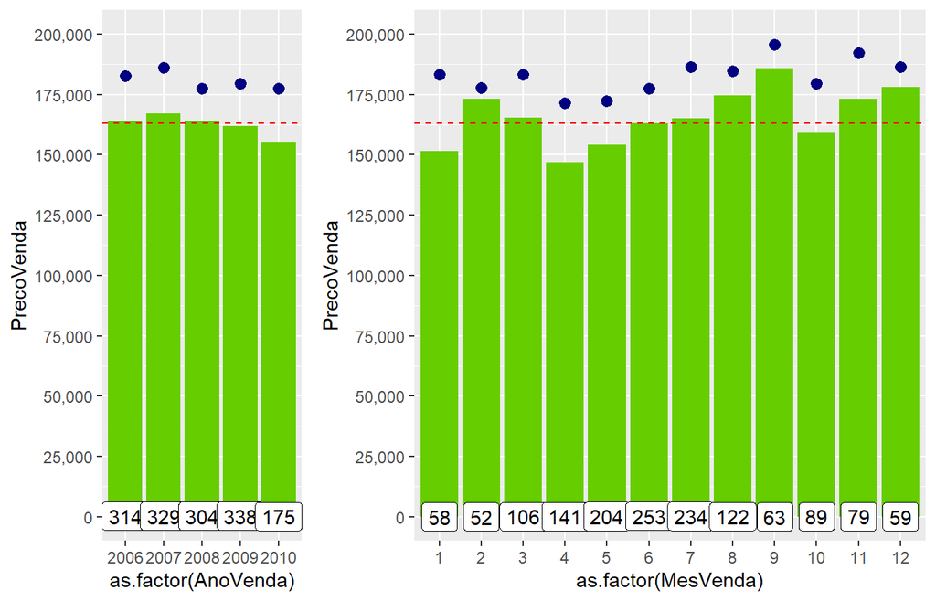

```r
ys <- ggplot(todas[!is.na(todas$PrecoVenda),], aes(x=as.factor(AnoVenda), y=PrecoVenda)) +
  geom_bar(stat='summary', fun = "median", fill='chartreuse3')+
  scale_y_continuous(breaks= seq(0, 800000, by=25000), labels = comma) +
  geom_label(stat = "count", aes(label = ..count.., y = ..count..)) +
  coord_cartesian(ylim = c(0, 200000)) +
  stat_summary(fun="mean", color="navyblue")+
  geom_hline(yintercept=163000, linetype="dashed", color = "red") #linha tracejada é a mediana do preço de venda

ms <- ggplot(todas[!is.na(todas$PrecoVenda),], aes(x=as.factor(MesVenda), y=PrecoVenda)) +
  geom_bar(stat='summary', fun = "median", fill='chartreuse3')+
  scale_y_continuous(breaks= seq(0, 800000, by=25000), labels = comma) +
  geom_label(stat = "count", aes(label = ..count.., y = ..count..)) +
  coord_cartesian(ylim = c(0, 200000)) +
  stat_summary(fun="mean", color="navyblue")+
  geom_hline(yintercept=163000, linetype="dashed", color = "red") #linha tracejada é a mediana do preço de venda

grid.arrange(ys, ms, widths=c(1,2))
```

Da mesma forma, a variável classe veio como numérica, mas na verdade cada número significa uma categoria.

```r
todas$Classe <- as.factor(todas$Classe)
table(todas$Classe)
```

```
##
##   20   30   40   45   50   60   70   75   80   85   90  120  150  160  180  190
## 1079  139    6   18  287  575  128   23  118   48  109  182    1  128   17   61
```

```r
todas$Classe <- revalue(todas$Classe, c('20'='1 story 1946+', '30'='1 story 1945-', '40'='1 story unf attic',
                                      '45'='1,5 story unf', '50'='1,5 story fin', '60'='2 story 1946+',
                                      '70'='2 story 1945-', '75'='2,5 story all ages', '80'='split/multi level',
                                      '85'='split foyer', '90'='duplex all style/age', '120'='1 story PUD 1946+',
                                      '150'='1,5 story PUD all', '160'='2 story PUD 1946+', '180'='PUD multilevel',
                                      '190'='2 family conversion'))
 table(todas$Classe)
```

```
##
##        1 story 1946+        1 story 1945-    1 story unf attic
##                 1079                  139                    6
##        1,5 story unf        1,5 story fin        2 story 1946+
##                   18                  287                  575
##        2 story 1945-   2,5 story all ages    split/multi level
##                  128                   23                  118
##          split foyer duplex all style/age    1 story PUD 1946+
##                   48                  109                  182
##    1,5 story PUD all    2 story PUD 1946+       PUD multilevel
##                    1                  128                   17
##  2 family conversion
##                   61
```

# 7 Correlações finais

Realizando a mesma análise da secão 3, com as novas variáveis numéricas.

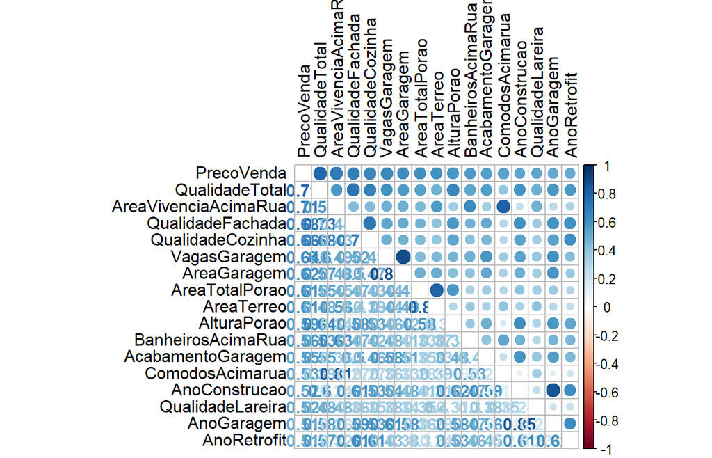

```r
numericVarsFin <- which(sapply(todas, is.numeric))
numericVarNamesFin <- names(numericVarsFin) # salvando os titulos como vetor
all_numericasFin <- todas[, numericVarsFin] # subset somente das numéricas
cor_numericasFin <- cor(all_numericasFin, use="pairwise.complete.obs") # correlações entre as numericas
cor_ordenadaFin <- as.matrix(sort(cor_numericasFin[,'PrecoVenda'], decreasing = TRUE)) #ordenando de forma decrescente

# Selecionando as altas, retornando para a matriz e plotado
cor_altaFin<- names(which(apply(cor_ordenadaFin, 1, function(x) abs(x)>0.5)))
cor_principaisnumFin <- cor_numericasFin[cor_altaFin, cor_altaFin]
corrplot.mixed(cor_principaisnumFin, tl.col="black", tl.pos = "lt")
```

A primeira matriz tinha 10 variáveis com correlação maior que 0,5 com o Preço de Venda. Agora, existem 16 variáveis com este nível de correlação

## 7.1 Importância de cada variável

Para uma análise mais profunda, será executado um algoritmo de classificação `Random Forest` com apenas 100 árvores para avaliar a importância de cada variável preditora no Preço de Venda.

O algoritmo entre 2 valores de imporância: o erro médio quadrado ao permutar aleatoriamente as variáveis e a pureza que aquela variável fornece ao conjunto. Com isso é possível criar um ranking de importância.

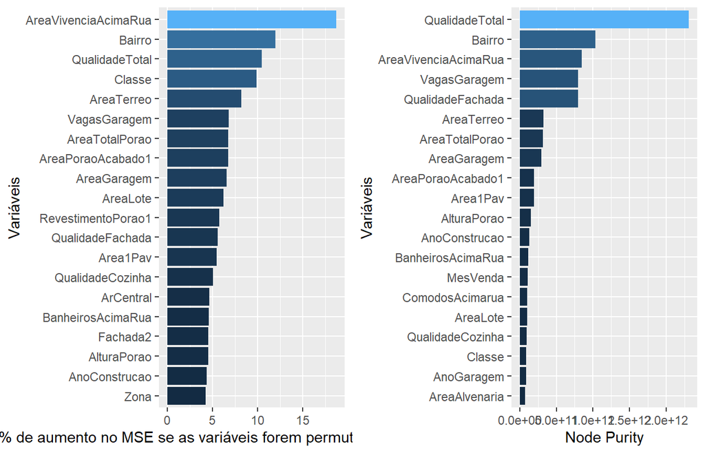

```r
set.seed(2020)

RF_rapido <- randomForest(x=todas[1:1460,-80], y=todas$PrecoVenda[1:1460], ntree=100,importance=TRUE)
imp_RF <- importance(RF_rapido)
imp_DF <- data.frame(Variables = row.names(imp_RF), MSE = imp_RF[,1])
imp_DF2 <- data.frame(Variables = row.names(imp_RF), nodepurity = imp_RF[,2])
imp_DF <- imp_DF[order(imp_DF$MSE, decreasing = TRUE),]
imp_DF2 <- imp_DF2[order(imp_DF2$nodepurity, decreasing = TRUE),]

imp1 <- ggplot(imp_DF[1:20,], aes(x=reorder(Variables, MSE), y=MSE, fill=MSE)) + geom_bar(stat = 'identity') +
  labs(x = 'Variáveis', y= '% de aumento no MSE se as variáveis forem permutadas randomicamente') + coord_flip() +
  theme(legend.position="none")

imp2 <- ggplot(imp_DF2[1:20,], aes(x=reorder(Variables, nodepurity), y=nodepurity, fill=nodepurity)) + geom_bar(stat = 'identity') +
  labs(x = 'Variáveis', y= 'Node Purity') + coord_flip() +
  theme(legend.position="none")

grid.arrange(imp1, imp2, widths=c(1,1))
```

Iremos considerar a importância com base no erro médio quadrático (MSE). Com isso, percebemos ligeiras diferenças entre a ordem vista na matriz de correlação. Este dado é de extrema importância para conhecimento organizacional do produto ou serviço, pois pode orientar e otimizar investimento de recursos e tempo nas variáveis mais importantes para uma variável-alvo escolhida (neste caso o Preço de Venda).

Tendo isso em vista, será realizada uma `Análise Exploratória de Dados` superficial para verificar se existe alguma relação clara entre as variáveis.

# 8 Análise exploratória de dados

## 8.1 Áreas

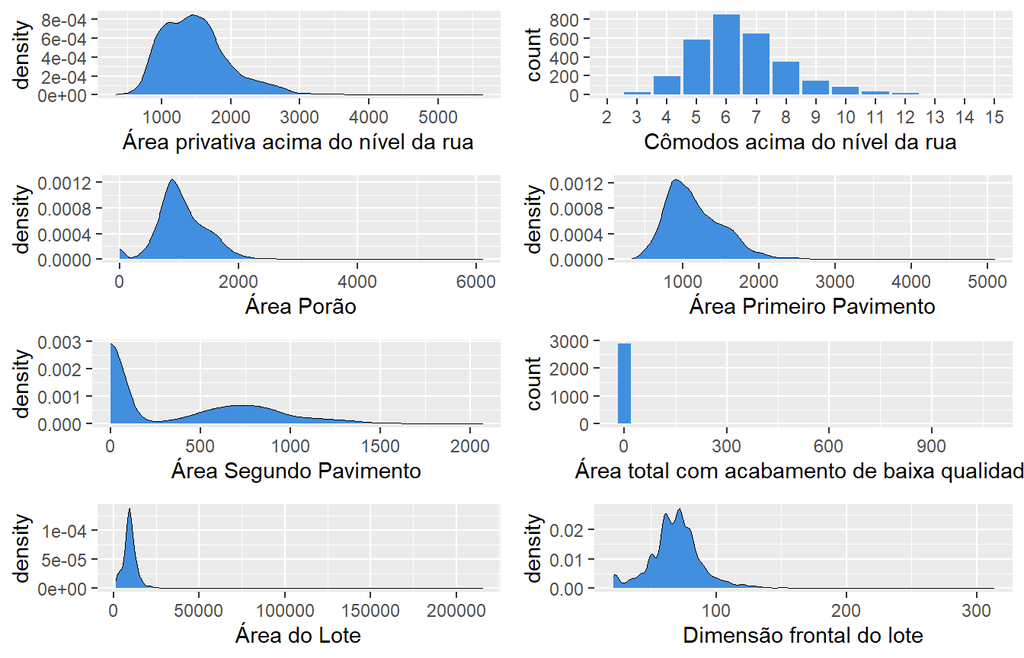

```r
s1 <- ggplot(todas, aes(x=AreaVivenciaAcimaRua)) +
  geom_density(fill='#418fde', size=0) + labs(x='Área privativa acima do nível da rua')

s2 <- ggplot(todas, aes(x=as.factor(ComodosAcimarua))) +
  geom_histogram(stat='count', fill='#418fde') + labs(x='Cômodos acima do nível da rua')

s3 <- ggplot(todas, aes(x=AreaTerreo)) +
  geom_density(fill='#418fde', size=0) + labs(x='Área Primeiro Pavimento')

s4 <- ggplot(todas, aes(x=Area1Pav)) +
  geom_density(fill='#418fde', size=0) + labs(x='Área Segundo Pavimento')

s5 <- ggplot(todas, aes(x=AreaTotalPorao)) +
  geom_density(fill='#418fde', size=0) + labs(x='Área Porão')

s6 <- ggplot(todas, aes(x=AreaLote)) +
  geom_density(fill='#418fde', size=0) + labs(x='Área do Lote')

s7 <- ggplot(todas, aes(x=DimFrontal)) +
  geom_density(fill='#418fde', size=0) + labs(x='Dimensão frontal do lote')

s8 <- ggplot(todas, aes(x=AreaAcabBaixaQualTotal)) +
  geom_histogram(fill='#418fde', size=0) + labs(x='Área total com acabamento de baixa qualidade')

layout <- matrix(c(1,2,5,3,4,8,6,7),4,2,byrow=TRUE)
multiplot(s1, s2, s3, s4, s5, s6, s7, s8, layout=layout)
```

```r
table(todas[1:1460,]$AreaAcabBaixaQualTotal)
```

```
##
##    0   53   80  120  144  156  205  232  234  360  371  384  390  392  397  420
## 1434    1    3    1    1    1    1    1    1    2    1    1    1    1    1    1
##  473  479  481  513  514  515  528  572
##    1    1    1    1    1    1    1    1
```

Observa-se que a Área privativa acima do nível da rua `AreaVivenciaAcimaRua` é - provavelmente - uma combinação das variáveis: `AreaTérreo`, `Area1Pav` e `AreaAcabBaixaQualTotal` (que pouquissimas casas possuem).

Para confirmar esta hipótese, será calculada a correlação da variável AreaVivenciaAcimaRua com a soma das outras 3 variáveis.

```r
cor(todas$AreaVivenciaAcimaRua, (todas$AreaTerreo + todas$Area1Pav + todas$AreaAcabBaixaQualTotal))
```

```
## [1] 1
```

## 8.2 Bairros

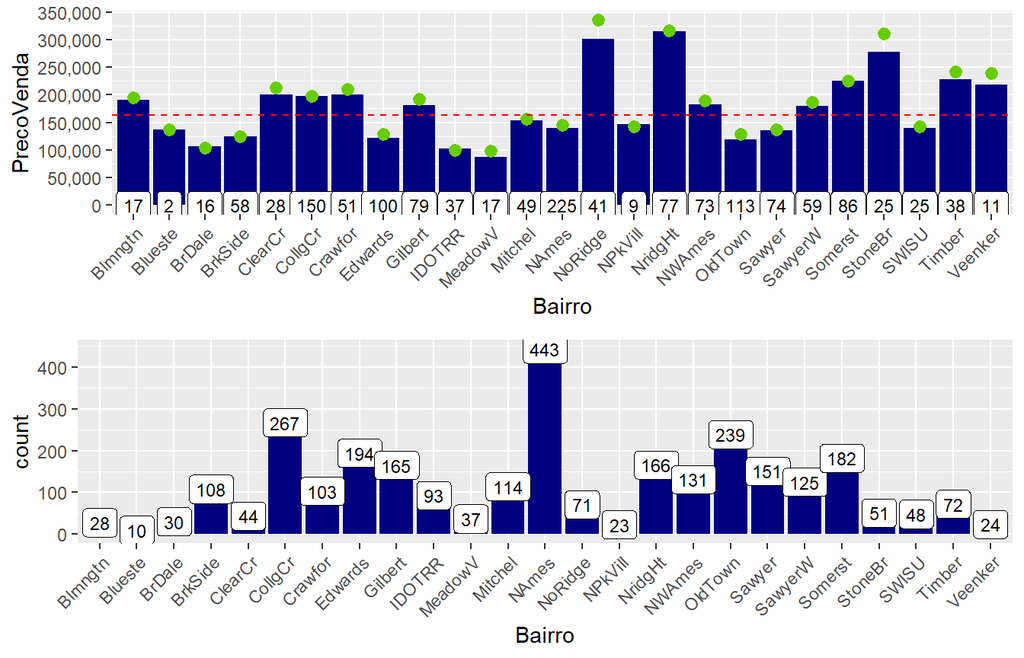

```r
bairros1 <- ggplot(todas[!is.na(todas$PrecoVenda),], aes(x=Bairro, y=PrecoVenda)) +
  geom_bar(stat='summary', fun = "median", fill='navyblue') +
  stat_summary(fun="mean", color="chartreuse3")+
  theme(axis.text.x = element_text(angle = 45, hjust = 1)) +
  scale_y_continuous(breaks= seq(0, 800000, by=50000), labels = comma) +
  geom_label(stat = "count", aes(label = ..count.., y = ..count..), size=3) +
  geom_hline(yintercept=163000, linetype="dashed", color = "red") #mediana todal do precovenda
bairros2 <- ggplot(todas, aes(x=Bairro)) +
  geom_histogram(stat='count', fill='navyblue')+
  geom_label(stat = "count", aes(label = ..count.., y = ..count..), size=3)+
  theme(axis.text.x = element_text(angle = 45, hjust = 1))
grid.arrange(bairros1, bairros2)
```

## 8.3 Qualidades

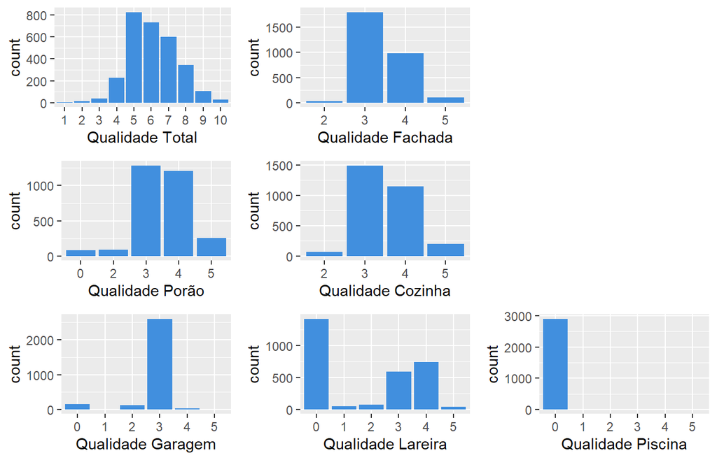

```r
q1 <- ggplot(todas, aes(x=as.factor(QualidadeTotal))) +
  geom_histogram(stat='count', fill='#418fde', size=0) + labs(x='Qualidade Total')
q2 <- ggplot(todas, aes(x=as.factor(QualidadeFachada))) +
  geom_histogram(stat='count', fill='#418fde', size=0) + labs(x='Qualidade Fachada')
q3 <- ggplot(todas, aes(x=as.factor(AlturaPorao))) +
  geom_histogram(stat='count', fill='#418fde', size=0) + labs(x='Qualidade Porão')
q4 <- ggplot(todas, aes(x=as.factor(QualidadeCozinha))) +
  geom_histogram(stat='count', fill='#418fde', size=0) + labs(x='Qualidade Cozinha')
q5 <- ggplot(todas, aes(x=as.factor(QualiGaragem))) +
  geom_histogram(stat='count', fill='#418fde', size=0) + labs(x='Qualidade Garagem')
q6 <- ggplot(todas, aes(x=as.factor(QualidadeLareira))) +
  geom_histogram(stat='count', fill='#418fde', size=0) + labs(x='Qualidade Lareira')
q7 <- ggplot(todas, aes(x=as.factor(QualiPiscina))) +
  geom_histogram(stat='count', fill='#418fde', size=0) + labs(x='Qualidade Piscina')

layout <- matrix(c(1,2,8,3,4,8,5,6,7),3,3,byrow=TRUE)
multiplot(q1, q2, q3, q4, q5, q6, q7, layout=layout)
```

## 8.4 Classes

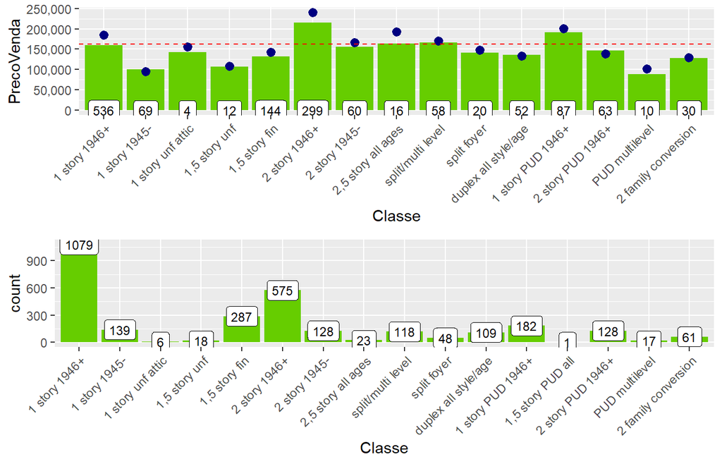

```r
classes1 <- ggplot(todas[!is.na(todas$PrecoVenda),], aes(x=Classe, y=PrecoVenda)) +
  geom_bar(stat='summary', fun = "median", fill='chartreuse3') +
  stat_summary(fun="mean", color= "navy")+
  theme(axis.text.x = element_text(angle = 45, hjust = 1)) +
  scale_y_continuous(breaks= seq(0, 800000, by=50000), labels = comma) +
  geom_label(stat = "count", aes(label = ..count.., y = ..count..), size=3) +
  geom_hline(yintercept=163000, linetype="dashed", color = "red") #mediana todal do precovenda
classes2 <- ggplot(todas, aes(x=Classe)) +
  geom_histogram(stat='count', fill='chartreuse3')+
  geom_label(stat = "count", aes(label = ..count.., y = ..count..), size=3)+
  theme(axis.text.x = element_text(angle = 45, hjust = 1))
grid.arrange(classes1, classes2)
```

## 8.5 Garagens

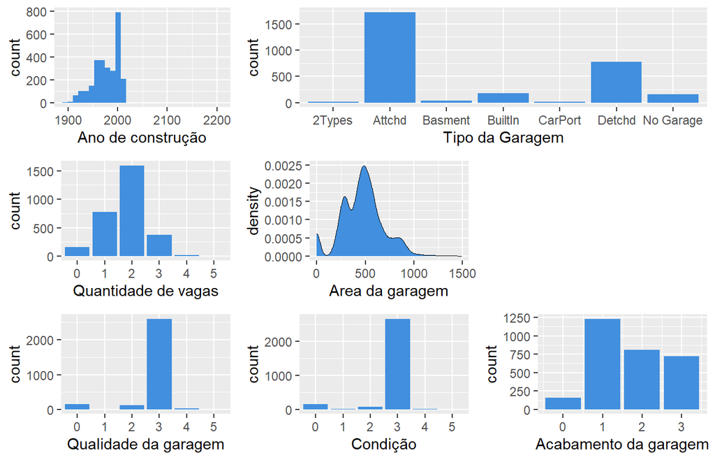

```r
g1 <- ggplot(todas[todas$VagasGaragem!=0,], aes(x=AnoGaragem)) +
  geom_histogram(fill='#418fde') + labs(x='Ano de construção')
g2 <- ggplot(todas, aes(x=as.factor(VagasGaragem))) +
  geom_histogram(stat='count', fill='#418fde', size=0) + labs(x='Quantidade de vagas')
g3 <- ggplot(todas, aes(x=AreaGaragem)) +
  geom_density(fill='#418fde', size=0) + labs(x='Area da garagem')
g4 <- ggplot(todas, aes(x=as.factor(CondicaoGaragem))) +
  geom_histogram(stat='count', fill='#418fde', size=0) + labs(x='Condição')
g5 <- ggplot(todas, aes(x=TipoGaragem)) +
  geom_histogram(stat='count', fill='#418fde', size=0) + labs(x='Tipo da Garagem')
g6 <- ggplot(todas, aes(x=as.factor(QualiGaragem))) +
  geom_histogram(stat='count', fill='#418fde', size=0) + labs(x='Qualidade da garagem')
g7 <- ggplot(todas, aes(x=AcabamentoGaragem)) +
  geom_histogram(stat='count', fill='#418fde', size=0) + labs(x='Acabamento da garagem')

layout <- matrix(c(1,5,5,2,3,8,6,4,7),3,3,byrow=TRUE)
multiplot(g1, g2, g3, g4, g5, g6, g7, layout=layout)
```

Existem muitas variáveis relacionadas à garagem, inclusive com alta correlação entre si. Pode ser interessante elimitar algumas.

Outro fator interessante é a escala do histograma do ano de construção da garagem. Provavelmente há algum erro de digitação em um dado puxando o eixo X gráfico para volta do ano 2200 mas que nao da pra ver na escala.

```r
todas[todas$AnoGaragem>2020,c('Id','AnoGaragem', 'AnoConstrucao')] #procurando erros de digitação
```

```
##        Id AnoGaragem AnoConstrucao
## 2593 2593       2207          2006
```

```r
todas$AnoGaragem[2593] <- 2007
```

Considerando o ano de construção, o ano da garagem foi corrigido para 2007.

## 8.6 Porão

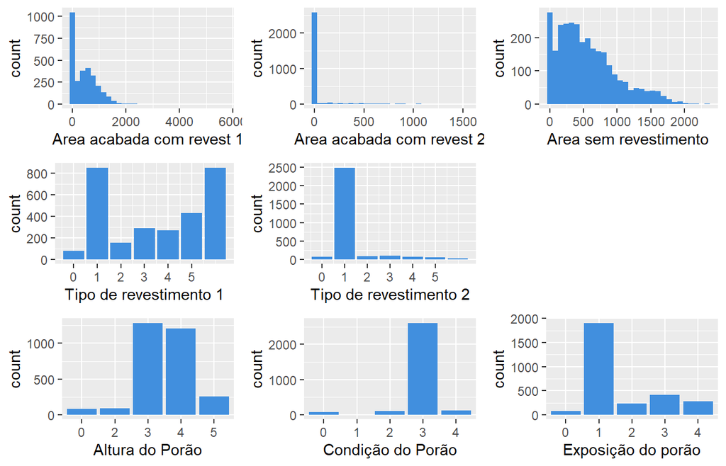

```r
b1 <- ggplot(todas, aes(x=AreaPoraoAcabado1)) +
  geom_histogram(fill='#418fde') + labs(x='Area acabada com revest 1')

b2 <- ggplot(todas, aes(x=AreaPoraoAcabado2)) +
  geom_histogram(fill='#418fde') + labs(x='Area acabada com revest 2')

b3 <- ggplot(todas, aes(x=AreaPoraoInacab)) +
  geom_histogram(fill='#418fde') + labs(x='Area sem revestimento')

b4 <- ggplot(todas, aes(x=RevestimentoPorao1)) +
  geom_histogram(stat='count', fill='#418fde') + labs(x='Tipo de revestimento 1')+
  scale_x_continuous(breaks=c(0,1,2,3,4,5))

b5 <- ggplot(todas, aes(x=RevestimentoPorao2)) +
  geom_histogram(stat='count', fill='#418fde') + labs(x='Tipo de revestimento 2')+
  scale_x_continuous(breaks=c(0,1,2,3,4,5))

b6 <- ggplot(todas, aes(x=as.factor(AlturaPorao))) +
  geom_histogram(stat='count', fill='#418fde') + labs(x='Altura do Porão')

b7 <- ggplot(todas, aes(x=as.factor(CondicaoPorao))) +
  geom_histogram(stat='count', fill='#418fde') + labs(x='Condição do Porão')

b8 <- ggplot(todas, aes(x=as.factor(ExposicaoPorao))) +
  geom_histogram(stat='count', fill='#418fde') + labs(x='Exposição do porão')

layout <- matrix(c(1,2,3,4,5,9,6,7,8),3,3,byrow=TRUE)
multiplot(b1, b2, b3, b4, b5, b6, b7, b8, layout=layout)
```

Tal qual as variáveis de área, suspeita-se que a variável de área total do porão (já plotada na seçao de áreas) seja a soma das áreas `AreaPoraoAcabado1`, `AreaPoraoAcabado2` e `AreaPoraoInacab`.

```r
cor(todas$AreaTotalPorao, (todas$AreaPoraoAcabado1 + todas$AreaPoraoAcabado2 + todas$AreaPoraoInacab))
```

```
## [1] 1
```

A correlação perfeita confirma a hipótese.

# 9 Feature Engineering

Nesta etapa serão avaliadas a inserção, substituição e descarte de algumas variáveis no modelo preditivo.

É valido lembrar que até aqui toda a etapa de Análise Exploratória de Dados (EDA) é fundamental para análises descritivas e diagnósticas, gerando conhecimento organizacional para a empresa. Deste momento em diante, o intuito é preparar os dados para uma melhor modelarem matemática da realidade por meio dos algoritmos de inteligência artificial.

Portanto, pode-se considerar um segundo produto com diferentes objetivos: prever o preço de venda de imóveis a partir dos parâmetros selecionados por esta etapa.

## 9.1 Banheiros

Existe uma grande quantidade de variáveis relacionadas a banheiros e que não apresentam importância isoladas. Desta forma, serão unidas em uma única variável para avaliar sua relevância.

Cada lavabo será considerado meio banheiro (conceito estadunidense de half-bathroom, onde existe apenas 3 itens - geralmente sem o chuveiro) e cada banheiro um “full bathroom”. Assim, será criada a variável `TotalBanheiros` e plotada em relação ao `Preço de Venda`.

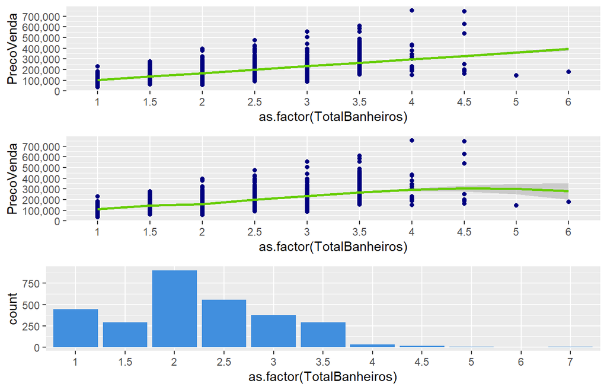

```r
todas$TotalBanheiros <- todas$BanheirosAcimaRua + todas$BanheirosPorao + (todas$LavaboPorao*0.5) + (todas$LavaboAcimaRua*0.5)

tb1 <- ggplot(todas[!is.na(todas$PrecoVenda),], aes(x=as.factor(TotalBanheiros), y=PrecoVenda))+
  geom_point(col='navy') + geom_smooth(method = "lm", color="chartreuse3", aes(group=1)) +
  scale_y_continuous(breaks= seq(0, 800000, by=100000), labels = comma)
tb2 <- ggplot(todas[!is.na(todas$PrecoVenda),], aes(x=as.factor(TotalBanheiros), y=PrecoVenda))+
  geom_point(col='navy') + geom_smooth(method = "loess", color="chartreuse3", aes(group=1)) +
  scale_y_continuous(breaks= seq(0, 800000, by=100000), labels = comma)
tb3 <- ggplot(todas, aes(x=as.factor(TotalBanheiros))) +
  geom_histogram(stat='count', fill='#418fde')

grid.arrange(tb1, tb2, tb3)
```

## 9.2 Vida útil

Tratando-se de variáveis temporais, uma que chama atenção é a variável `Retrofit` (Remodel no conjunto original). Para avaliar sua relação, será criado uma variavel binária para casos em que houve retrofit ou não (0-não houve, 1-houve).

Também será avaliado a idade todal da edificação, sendo (ano da venda - ano do retrofit). Nos casos em que não há retrofit, o ano preenchido para o retrofit é o mesmo da construção, o que não gerará problemas.

```r
# criando novas colunas / variáveis
todas$Retrofit <- ifelse(todas$AnoConstrucao==todas$AnoRetrofit, 0, 1)
todas$idade <- as.numeric(todas$AnoVenda)-todas$AnoRetrofit
```

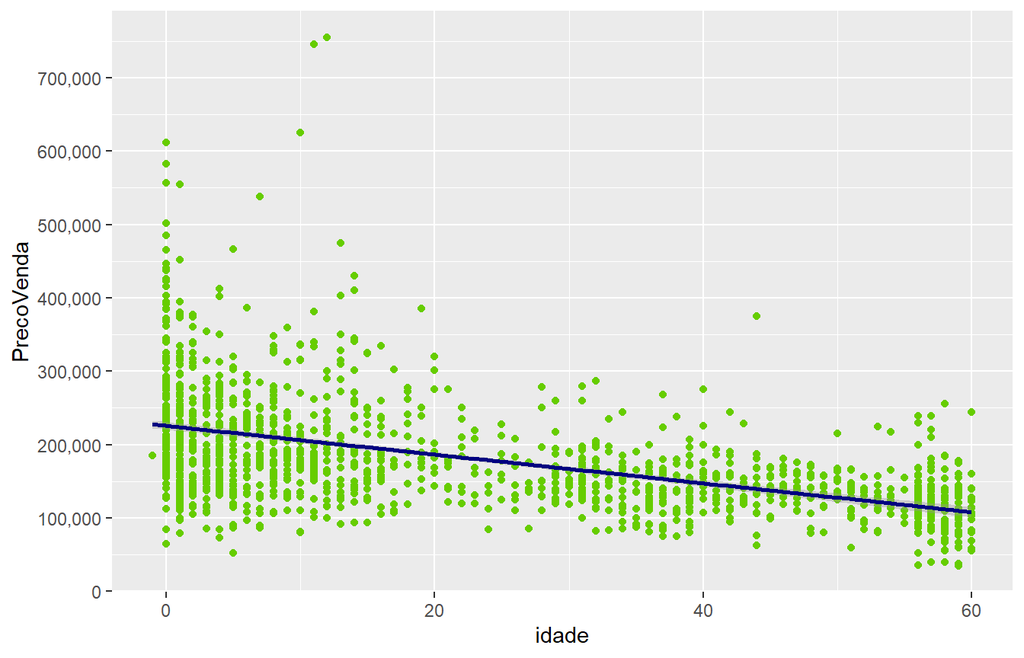

```r
ggplot(todas[!is.na(todas$PrecoVenda),], aes(x=idade, y=PrecoVenda))+
  geom_point(col='chartreuse3') + geom_smooth(method = "lm", color="navy", aes(group=1)) +
  scale_y_continuous(breaks= seq(0, 800000, by=100000), labels = comma)
```

```r
cor(todas$PrecoVenda[!is.na(todas$PrecoVenda)], todas$idade[!is.na(todas$PrecoVenda)])
```

```
## [1] -0.5090787
```

Como esperado, há uma correlação negativa entre a idade do imóvel e seu preço de venda

Avaliando se o retrofit impacta no preço:

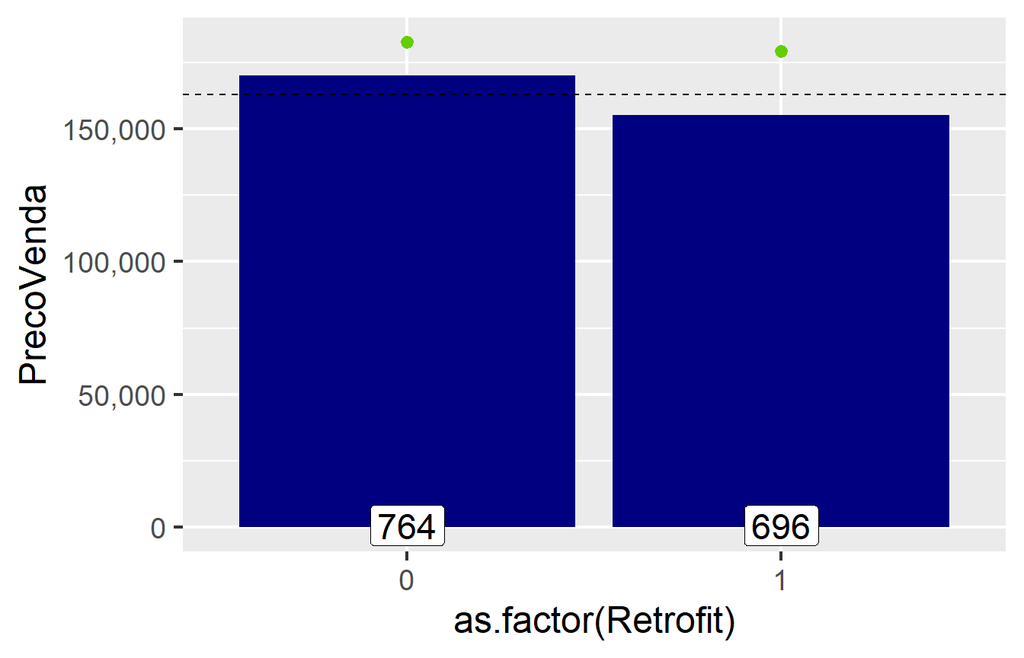

```r
ggplot(todas[!is.na(todas$PrecoVenda),], aes(x=as.factor(Retrofit), y=PrecoVenda)) +
  geom_bar(stat='summary', fun = "median", fill='navyblue') +
  geom_label(stat = "count", aes(label = ..count.., y = ..count..), size=6) +
  scale_y_continuous(breaks= seq(0, 800000, by=50000), labels = comma) +
  theme_grey(base_size = 18) +
  geom_hline(yintercept=163000, linetype="dashed")+
  stat_summary(fun="mean", color='chartreuse3')
```

Sim, impacta negativamente. Lembrando que a linha tracejada é a mediana dos preços de venda, o ponto verde a média do preço de venda de cada categoria e a altura da barra a mediana.

Será criada uma nova variável binária: se a cara foi vendida nova:

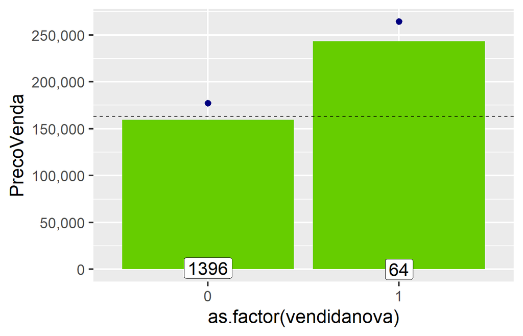

```r
todas$vendidanova <- ifelse(todas$AnoVenda==todas$AnoConstrucao, 1, 0)

ggplot(todas[!is.na(todas$PrecoVenda),], aes(x=as.factor(vendidanova), y=PrecoVenda)) +
  geom_bar(stat='summary', fun = "median", fill='chartreuse3') +
  geom_label(stat = "count", aes(label = ..count.., y = ..count..), size=6) +
  scale_y_continuous(breaks= seq(0, 800000, by=50000), labels = comma) +
  theme_grey(base_size = 18) +
  geom_hline(yintercept=163000, linetype="dashed")+
  stat_summary(fun="mean", color= "navy")
```

```r
todas$AnoVenda <- as.factor(todas$AnoVenda)
```

Observa-se, como esperado, um impacto significativo no preço de venda.

## 9.3 Bairros

Como já observado, existe uma grande variação do preço de venda de acordo com o bairro. Apesar de não existir ordinalidade, esta relação não pode ser descartada.

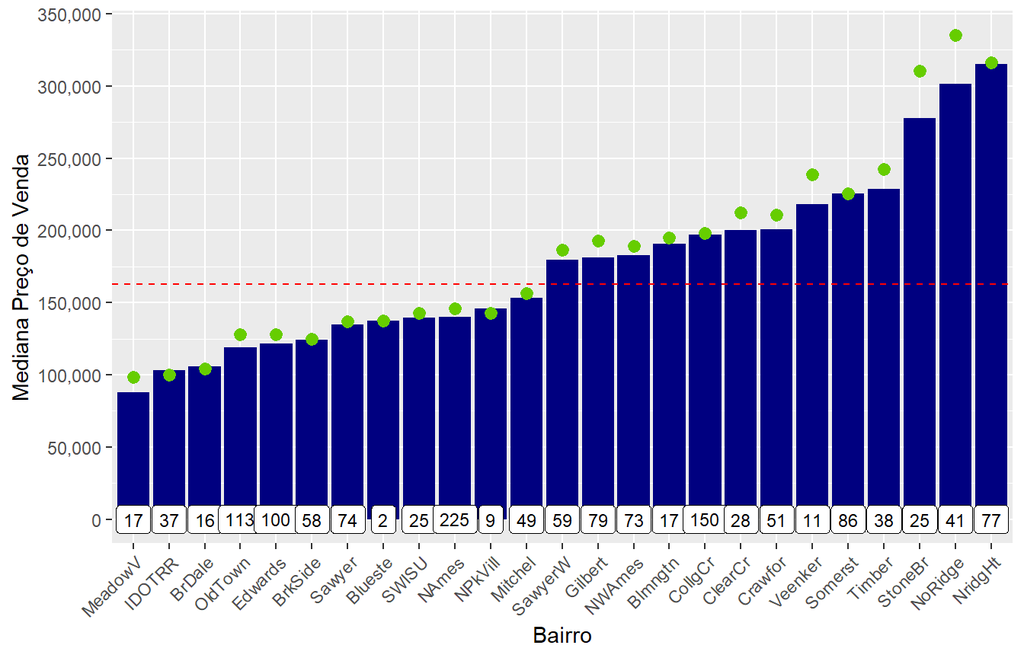

```r
ggplot(todas[!is.na(todas$PrecoVenda),], aes(x=reorder(Bairro, PrecoVenda, FUN=median), y=PrecoVenda)) +
  geom_bar(stat='summary', fun = "median", fill='navy') + labs(x='Bairro', y='Mediana Preço de Venda') +
  theme(axis.text.x = element_text(angle = 45, hjust = 1)) +
  scale_y_continuous(breaks= seq(0, 800000, by=50000), labels = comma) +
  geom_label(stat = "count", aes(label = ..count.., y = ..count..), size=3) +
  stat_summary(fun="mean", color= "chartreuse3") +
  geom_hline(yintercept=163000, linetype="dashed", color = "red")
```

Para isso, será considerado 3 diferentes categorias: 0, 1 e 2 onde a mediana sofre alterações mais visíveis.

```r
todas$bairrosricos[todas$Bairro %in% c('StoneBr', 'NridgHt', 'NoRidge')] <- 2
todas$bairrosricos[!todas$Bairro %in% c('MeadowV', 'IDOTRR', 'BrDale', 'StoneBr', 'NridgHt', 'NoRidge')] <- 1
todas$bairrosricos[todas$Bairro %in% c('MeadowV', 'IDOTRR', 'BrDale')] <- 0
```

## 9.4 Áreas

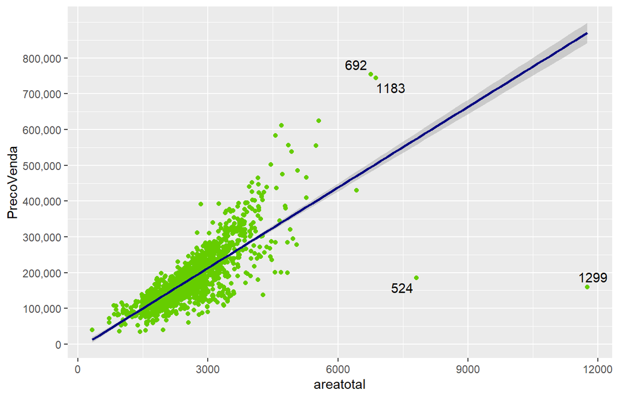

```r
todas$areatotal <- todas$AreaVivenciaAcimaRua + todas$AreaTotalPorao

ggplot(todas[!is.na(todas$PrecoVenda),], aes(x=areatotal, y=PrecoVenda))+
  geom_point(col='chartreuse3') + geom_smooth(method = "lm", color="navy", aes(group=1)) +
  scale_y_continuous(breaks= seq(0, 800000, by=100000), labels = comma) +
  geom_text_repel(aes(label = ifelse(todas$AreaVivenciaAcimaRua[!is.na(todas$PrecoVenda)]>4000, rownames(todas), '')))
```

```r
cor(todas$PrecoVenda, todas$areatotal, use= "pairwise.complete.obs")
```

```
## [1] 0.7789588
```

A relação, como esperado, é ainda mais acentuada que a análise preliminar realizada apenas com `AreaVivenciaAcimaRua`.

A correlaçào será reavaliada sem os 2 ouliers abaixo da regressão.

```r
cor(todas$PrecoVenda[-c(524, 1299)], todas$areatotal[-c(524, 1299)], use= "pairwise.complete.obs")
```

```
## [1] 0.829042
```

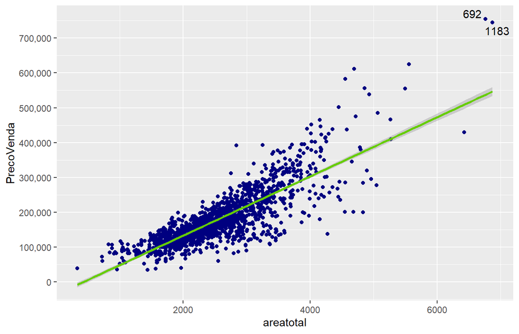

```r
todas <- todas[-c(524,1299),]

ggplot(todas[!is.na(todas$PrecoVenda),], aes(x=areatotal, y=PrecoVenda))+
  geom_point(col='navy') + geom_smooth(method = "lm", color="chartreuse3", aes(group=1)) +
  scale_y_continuous(breaks= seq(0, 800000, by=100000), labels = comma) +
  geom_text_repel(aes(label = ifelse(todas$AreaVivenciaAcimaRua[!is.na(todas$PrecoVenda)]>4000, rownames(todas), '')))
```

## 9.5 Varandas

Por definição dos parâmetros, existem 4 variáveis para área de varanda que sozinhas não imactam de forma significativa no preço de venda. As áreas serão somadas em uma nova variável para avaliar a correlação conjunta.

```r
todas$areatotalvaranda <- (todas$AreaVarandaAberta + todas$AreaVarandaFechada + todas$AreaVarandaScreen + todas$AreaVaranda3Sea)


v1 <- ggplot(todas[!is.na(todas$PrecoVenda),], aes(x=AreaVarandaAberta, y=PrecoVenda))+
  geom_point(col='chartreuse3') + geom_smooth(method = "lm", color="navy", aes(group=1)) +
  scale_y_continuous(breaks= seq(0, 800000, by=100000), labels = comma)
cor(todas$PrecoVenda, todas$AreaVarandaAberta, use= "pairwise.complete.obs")
```

```
## [1] 0.3211424
```

```r
v2 <- ggplot(todas[!is.na(todas$PrecoVenda),], aes(x=AreaVarandaFechada , y=PrecoVenda))+
  geom_point(col='chartreuse3') + geom_smooth(method = "lm", color="navy", aes(group=1)) +
  scale_y_continuous(breaks= seq(0, 800000, by=100000), labels = comma)
cor(todas$PrecoVenda, todas$AreaVarandaFechada, use= "pairwise.complete.obs")
```

```
## [1] -0.1286456
```

```r
v3 <- ggplot(todas[!is.na(todas$PrecoVenda),], aes(x=AreaVarandaScreen, y=PrecoVenda))+
  geom_point(col='chartreuse3') + geom_smooth(method = "lm", color="navy", aes(group=1)) +
  scale_y_continuous(breaks= seq(0, 800000, by=100000), labels = comma)
cor(todas$PrecoVenda, todas$AreaVarandaScreen, use= "pairwise.complete.obs")
```

```
## [1] 0.111415
```

```r
v4<- ggplot(todas[!is.na(todas$PrecoVenda),], aes(x=AreaVaranda3Sea, y=PrecoVenda))+
  geom_point(col='chartreuse3') + geom_smooth(method = "lm", color="navy", aes(group=1)) +
  scale_y_continuous(breaks= seq(0, 800000, by=100000), labels = comma)
cor(todas$PrecoVenda, todas$AreaVaranda3Sea, use= "pairwise.complete.obs")
```

```
## [1] 0.044568
```

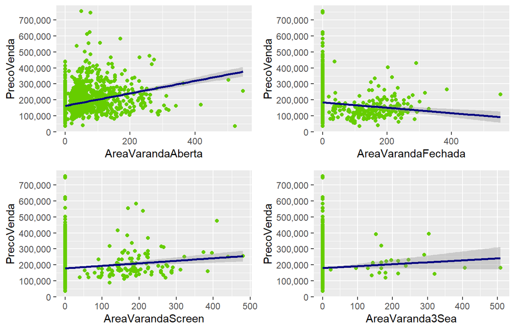

```r
grid.arrange(v1,v2,v3,v4)
```

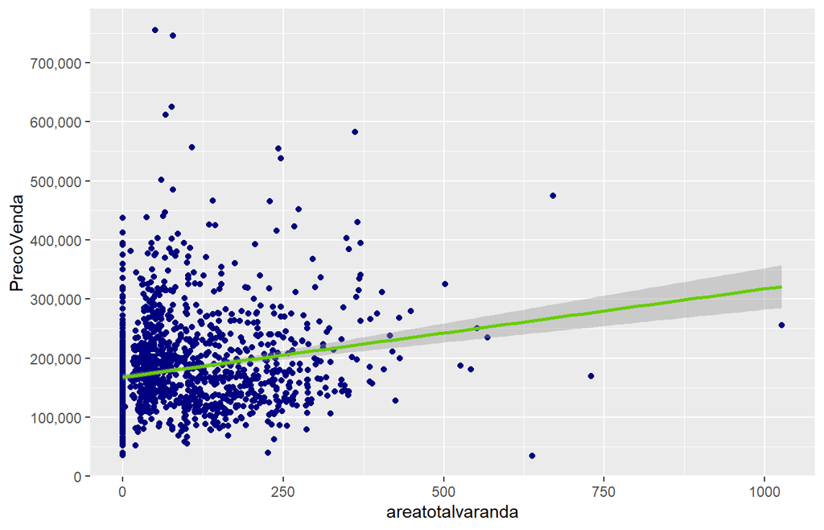

```r
ggplot(todas[!is.na(todas$PrecoVenda),], aes(x=areatotalvaranda, y=PrecoVenda))+
  geom_point(col='navy') + geom_smooth(method = "lm", color="chartreuse3", aes(group=1)) +
  scale_y_continuous(breaks= seq(0, 800000, by=100000), labels = comma)
```

```r
cor(todas$PrecoVenda, todas$areatotalvaranda, use= "pairwise.complete.obs")
```

```
## [1] 0.196875
```

Apesar de tudo, correlação não significativa.

## 9.6 Preparação para modelagem

Nesta etapa serão descartadas as variáveis escolhidas e divididas entre numéricas e fatores. As variáveis descartadas foram: `AnoRetrofit`, `AnoGaragem`, `ÁreaGaragem`, `CondicaoGaragem`,`AreaTotalPorao`, `ComodosAcimarua`, `AreaPoraoAcabado1`.

```r
variaveisdescartadas <- c('AnoRetrofit','AnoGaragem', 'AreaGaragem', 'CondicaoGaragem', 'AreaTotalPorao', 'ComodosAcimarua', 'AreaPoraoAcabado1')

todas <- todas[,!(names(todas) %in% variaveisdescartadas)]

numericVarNames<- numericVarNames[!(numericVarNames %in% c('Classe', 'MesVenda', 'AnoVenda', 'PrecoVenda', 'QualidadeTotal', 'CondicaoTotal'))] #numericVarNames was created before having done anything
numericVarNames <- append(numericVarNames, c('idade', 'areatotalvaranda', 'TotalBanheiros', 'areatotal'))
glimpse(todas)
```

```
## Rows: 2,917
## Columns: 80
## $ Id                     <int> 1, 2, 3, 4, 5, 6, 7, 8, 9, 10, 11, 12, 13, 1...
## $ Classe                 <fct> "2 story 1946+", "1 story 1946+", "2 story 1...
## $ Zona                   <fct> RL, RL, RL, RL, RL, RL, RL, RL, RM, RL, RL, ...
## $ DimFrontal             <int> 65, 80, 68, 60, 84, 85, 75, 80, 51, 50, 70, ...
## $ AreaLote               <int> 8450, 9600, 11250, 9550, 14260, 14115, 10084...
## $ TipoEstrada            <int> 1, 1, 1, 1, 1, 1, 1, 1, 1, 1, 1, 1, 1, 1, 1,...
## $ TipoRua                <fct> None, None, None, None, None, None, None, No...
## $ RelevoLote             <int> 3, 3, 2, 2, 2, 2, 3, 2, 3, 3, 3, 2, 1, 2, 2,...
## $ GreideLote             <fct> Lvl, Lvl, Lvl, Lvl, Lvl, Lvl, Lvl, Lvl, Lvl,...
## $ ImplantacaoLote        <fct> Inside, FR2, Inside, Corner, FR2, Inside, In...
## $ Declive                <int> 2, 2, 2, 2, 2, 2, 2, 2, 2, 2, 2, 2, 2, 2, 2,...
## $ Bairro                 <fct> CollgCr, Veenker, CollgCr, Crawfor, NoRidge,...
## $ Proximidade1           <fct> Norm, Feedr, Norm, Norm, Norm, Norm, Norm, P...
```

[output cut: 67 more lines]

```r
DFnumeric <- todas[, names(todas) %in% numericVarNames]

DFfactors <- todas[, !(names(todas) %in% numericVarNames)]
DFfactors <- DFfactors[, names(DFfactors) != 'PrecoVenda']

DFnumeric$Id <- NULL

cat('Existem', length(DFnumeric), 'variáveis numéricas e', length(DFfactors), 'variáveis categóricas')
```

```
## Existem 29 variáveis numéricas e 49 variáveis categóricas
```

## 9.7 Assimetria

Será aplicado o `log+1` para variáveis com assimetria maior que 0,8.

```r
for(i in 1:ncol(DFnumeric)){
  if (abs(skew(DFnumeric[,i]))>0.8){
    DFnumeric[,i] <- log(DFnumeric[,i] +1)
  }
}
```

## 9.8 Normalização

Normalização das variáveis.

```r
PreNum <- preProcess(DFnumeric, method=c("center", "scale"))
print(PreNum)
```

```
## Created from 2917 samples and 29 variables
##
## Pre-processing:
##   - centered (29)
##   - ignored (0)
##   - scaled (29)
```

```r
DFnorm <- predict(PreNum, DFnumeric)
dim(DFnorm)
```

```
## [1] 2917   29
```

## 9.9 One-hot encoding

Este processo consiste em transformar variáveis categóricas em numéricas a partir da criação de uma coluna para cada categoria. Assim os valores presentes são somente 0 e 1.

```r
DFdummies <- as.data.frame(model.matrix(~.-1, DFfactors))
dim(DFdummies)
```

```
## [1] 2917  201
```

## 9.10 Eliminando variáveis

Serão eliminadas as colunas de categorias que possuem zero ou poucas (<10) observações

### 9.10.1 Categorias sem observações no teste:

```r
colunaszeradasteste <- which(colSums(DFdummies[(nrow(todas[!is.na(todas$PrecoVenda),])+1):nrow(todas),])==0)
colnames(DFdummies[colunaszeradasteste])
```

```
##  [1] "Proximidade2RRAe"         "Proximidade2RRAn"
##  [3] "Proximidade2RRNn"         "Pavimentos2.5Fin"
##  [5] "MaterialCoberturaMembran" "MaterialCoberturaMetal"
##  [7] "MaterialCoberturaRoll"    "Fachada1ImStucc"
##  [9] "Fachada1Stone"            "Fachada2Other"
## [11] "AquecimentoOthW"          "SistemaEletricoMix"
## [13] "OutrosItensTenC"
```

```r
DFdummies <- DFdummies[,-colunaszeradasteste]
```

### 9.10.2 Categorias sem observações no treinamento:

```r
colunaszeradastrain <- which(colSums(DFdummies[1:nrow(todas[!is.na(todas$PrecoVenda),]),])==0)
colnames(DFdummies[colunaszeradastrain])
```

```
## [1] "Classe1,5 story PUD all"
```

```r
DFdummies <- DFdummies[,-colunaszeradastrain]
```

### 9.10.3 Categorias com menos de 10 observações no treinamento

```r
colunaspoucastrain <- which(colSums(DFdummies[1:nrow(todas[!is.na(todas$PrecoVenda),]),])<10)
colnames(DFdummies[colunaspoucastrain])
```

```
##  [1] "Classe1 story unf attic"  "ImplantacaoLoteFR3"
##  [3] "BairroBlueste"            "BairroNPkVill"
##  [5] "Proximidade1PosA"         "Proximidade1RRNe"
##  [7] "Proximidade1RRNn"         "Proximidade2Feedr"
##  [9] "Proximidade2PosA"         "Proximidade2PosN"
## [11] "TipoCoberturaMansard"     "TipoCoberturaShed"
## [13] "MaterialCoberturaWdShake" "MaterialCoberturaWdShngl"
## [15] "Fachada1AsphShn"          "Fachada1BrkComm"
## [17] "Fachada1CBlock"           "Fachada2AsphShn"
## [19] "Fachada2Brk Cmn"          "Fachada2CBlock"
## [21] "Fachada2Stone"            "FundacaoStone"
## [23] "FundacaoWood"             "AquecimentoGrav"
## [25] "AquecimentoWall"          "SistemaEletricoFuseP"
## [27] "TipoGaragemCarPort"       "OutrosItensOthr"
## [29] "TipoVendaCon"             "TipoVendaConLD"
## [31] "TipoVendaConLI"           "TipoVendaConLw"
## [33] "TipoVendaCWD"             "TipoVendaOth"
## [35] "CondicaoVendaAdjLand"
```

```r
DFdummies <- DFdummies[,-colunaspoucastrain]
```

### 9.10.4 Dataset combinado

```r
combined <- cbind(DFnorm, DFdummies)
dim(DFdummies)
```

```
## [1] 2917  152
```

```r
dim(combined)
```

```
## [1] 2917  181
```